# Capstone Project: Create a Customer Segmentation Report for Arvato Financial Services

In this project, you will analyze demographics data for customers of a mail-order sales company in Germany, comparing it against demographics information for the general population. You'll use unsupervised learning techniques to perform customer segmentation, identifying the parts of the population that best describe the core customer base of the company. Then, you'll apply what you've learned on a third dataset with demographics information for targets of a marketing campaign for the company, and use a model to predict which individuals are most likely to convert into becoming customers for the company. The data that you will use has been provided by our partners at Bertelsmann Arvato Analytics, and represents a real-life data science task.

The versions of those two datasets used in this project will include many more features and has not been pre-cleaned. You are also free to choose whatever approach you'd like to analyzing the data rather than follow pre-determined steps. In your work on this project, make sure that you carefully document your steps and decisions, since your main deliverable for this project will be a blog post reporting your findings.

```python
import os
import time
import numpy as np
import pandas as pd
import matplotlib.pyplot as plt
import seaborn as sns

from sklearn.metrics import fbeta_score
from sklearn.metrics import accuracy_score
from sklearn.preprocessing import StandardScaler
from sklearn.decomposition import PCA

from sklearn.cluster import KMeans
from sklearn.linear_model import LogisticRegression
from sklearn.tree import DecisionTreeClassifier
from sklearn.ensemble import RandomForestClassifier
from sklearn.ensemble import GradientBoostingRegressor, AdaBoostRegressor
from sklearn.ensemble import AdaBoostClassifier, GradientBoostingClassifier



from sklearn.model_selection import GridSearchCV


from sklearn.metrics import accuracy_score, roc_auc_score, confusion_matrix
from sklearn.model_selection import train_test_split, cross_val_score


# magic word for producing visualizations in notebook
%matplotlib inline

# For displaying max number of lines
pd.set_option("display.max_rows", 500)

# For reproducability
SEED = 2
```

## Part 0: Get to Know the Data

Each row of the demographics files represents a single person, but also includes information outside of individuals, including information about their household, building, and neighborhood. Use the information from the first two files to figure out how customers ("CUSTOMERS") are similar to or differ from the general population at large ("AZDIAS"), then use your analysis to make predictions on the other two files ("MAILOUT"), predicting which recipients are most likely to become a customer for the mail-order company.

The "CUSTOMERS" file contains three extra columns ('CUSTOMER_GROUP', 'ONLINE_PURCHASE', and 'PRODUCT_GROUP'), which provide broad information about the customers depicted in the file. The original "MAILOUT" file included one additional column, "RESPONSE", which indicated whether or not each recipient became a customer of the company. For the "TRAIN" subset, this column has been retained, but in the "TEST" subset it has been removed; it is against that withheld column that your final predictions will be assessed in the Kaggle competition.

Otherwise, all of the remaining columns are the same between the three data files. For more information about the columns depicted in the files, you can refer to two Excel spreadsheets provided in the workspace. One of them is a top-level list of attributes and descriptions, organized by informational category. The other is a detailed mapping of data values for each feature in alphabetical order.

In the below cell, we've provided some initial code to load in the first two datasets. Note for all of the `.csv` data files in this project that they're semicolon (`;`) delimited, so an additional argument in the [`read_csv()`](https://pandas.pydata.org/pandas-docs/stable/generated/pandas.read_csv.html) call has been included to read in the data properly. Also, considering the size of the datasets, it may take some time for them to load completely.

You'll notice when the data is loaded in that a warning message will immediately pop up. Before you really start digging into the modeling and analysis, you're going to need to perform some cleaning. Take some time to browse the structure of the data and look over the informational spreadsheets to understand the data values. Make some decisions on which features to keep, which features to drop, and if any revisions need to be made on data formats. It'll be a good idea to create a function with pre-processing steps, since you'll need to clean all of the datasets before you work with them.

```python
# load in the data
azdias1 = pd.read_csv('../../data/Term2/capstone/arvato_data/Udacity_AZDIAS_052018.csv', sep=';')
customers1 = pd.read_csv('../../data/Term2/capstone/arvato_data/Udacity_CUSTOMERS_052018.csv', sep=';')
```

```
/opt/conda/lib/python3.6/site-packages/IPython/core/interactiveshell.py:2785: DtypeWarning: Columns (18,19) have mixed types. Specify dtype option on import or set low_memory=False.
  interactivity=interactivity, compiler=compiler, result=result)
```

### Exploratory Analysis

Let us examine the azdias dataset to see what it looks like:

```python
azdias1.head()
```

|  | LNR | AGER_TYP | AKT_DAT_KL | ALTER_HH | ALTER_KIND1 | ALTER_KIND2 | ALTER_KIND3 | ALTER_KIND4 | ALTERSKATEGORIE_FEIN | ANZ_HAUSHALTE_AKTIV | ... | VHN | VK_DHT4A | VK_DISTANZ | VK_ZG11 | W_KEIT_KIND_HH | WOHNDAUER_2008 | WOHNLAGE | ZABEOTYP | ANREDE_KZ | ALTERSKATEGORIE_GROB |
| --- | --- | --- | --- | --- | --- | --- | --- | --- | --- | --- | --- | --- | --- | --- | --- | --- | --- | --- | --- | --- | --- |
| 0 | 910215 | -1 | NaN | NaN | NaN | NaN | NaN | NaN | NaN | NaN | ... | NaN | NaN | NaN | NaN | NaN | NaN | NaN | 3 | 1 | 2 |
| 1 | 910220 | -1 | 9.0 | 0.0 | NaN | NaN | NaN | NaN | 21.0 | 11.0 | ... | 4.0 | 8.0 | 11.0 | 10.0 | 3.0 | 9.0 | 4.0 | 5 | 2 | 1 |
| 2 | 910225 | -1 | 9.0 | 17.0 | NaN | NaN | NaN | NaN | 17.0 | 10.0 | ... | 2.0 | 9.0 | 9.0 | 6.0 | 3.0 | 9.0 | 2.0 | 5 | 2 | 3 |
| 3 | 910226 | 2 | 1.0 | 13.0 | NaN | NaN | NaN | NaN | 13.0 | 1.0 | ... | 0.0 | 7.0 | 10.0 | 11.0 | NaN | 9.0 | 7.0 | 3 | 2 | 4 |
| 4 | 910241 | -1 | 1.0 | 20.0 | NaN | NaN | NaN | NaN | 14.0 | 3.0 | ... | 2.0 | 3.0 | 5.0 | 4.0 | 2.0 | 9.0 | 3.0 | 4 | 1 | 3 |

5 rows × 366 columns

```python
azdias1.shape
```

```
(891221, 366)
```

```python
azdias1.info()
```

```
<class 'pandas.core.frame.DataFrame'>
RangeIndex: 891221 entries, 0 to 891220
Columns: 366 entries, LNR to ALTERSKATEGORIE_GROB
dtypes: float64(267), int64(93), object(6)
memory usage: 2.4+ GB
```

```python
a = ['AGER_TYP','ALTERSKATEGORIE_GROB','ANREDE_KZ','CJT_GESAMTTYP','FINANZ_MINIMALIST','FINANZ_SPARER','FINANZ_VORSORGER','FINANZ_ANLEGER','FINANZ_UNAUFFAELLIGER','FINANZ_HAUSBAUER','FINANZTYP', 'GEBURTSJAHR','GFK_URLAUBERTYP','GREEN_AVANTGARDE',
 'HEALTH_TYP', 'LP_LEBENSPHASE_FEIN', 'LP_LEBENSPHASE_GROB','LP_FAMILIE_FEIN','LP_FAMILIE_GROB', 'LP_STATUS_FEIN', 'LP_STATUS_GROB', 'NATIONALITAET_KZ', 'PRAEGENDE_JUGENDJAHRE', 'RETOURTYP_BK_S', 'SEMIO_SOZ',
 'SEMIO_FAM','SEMIO_REL','SEMIO_MAT','SEMIO_VERT','SEMIO_LUST','SEMIO_ERL','SEMIO_KULT','SEMIO_RAT','SEMIO_KRIT','SEMIO_DOM', 'SEMIO_KAEM', 'SEMIO_PFLICHT','SEMIO_TRADV','SHOPPER_TYP','SOHO_KZ',
 'TITEL_KZ','VERS_TYP','ZABEOTYP','ALTER_HH','ANZ_PERSONEN','ANZ_TITEL','HH_EINKOMMEN_SCORE','KK_KUNDENTYP','W_KEIT_KIND_HH','WOHNDAUER_2008','ANZ_HAUSHALTE_AKTIV','ANZ_HH_TITEL','GEBAEUDETYP','KONSUMNAEHE','MIN_GEBAEUDEJAHR','OST_WEST_KZ','WOHNLAGE','CAMEO_DEUG_2015','CAMEO_DEU_2015','CAMEO_INTL_2015','KBA05_ANTG1',
 'KBA05_ANTG2','KBA05_ANTG3','KBA05_ANTG4','KBA05_BAUMAX','KBA05_GBZ','BALLRAUM','EWDICHTE','INNENSTADT','GEBAEUDETYP_RASTER','KKK','MOBI_REGIO','ONLINE_AFFINITAET','REGIOTYP','KBA13_ANZAHL_PKW','PLZ8_ANTG1','PLZ8_ANTG2','PLZ8_ANTG3','PLZ8_ANTG4','PLZ8_BAUMAX','PLZ8_HHZ','PLZ8_GBZ','ARBEIT','ORTSGR_KLS9','RELAT_AB']
```

```python
#azdias1.describe()
```

Let us exmine the customers dataset as well

```python
customers1.head()
```

|  | LNR | AGER_TYP | AKT_DAT_KL | ALTER_HH | ALTER_KIND1 | ALTER_KIND2 | ALTER_KIND3 | ALTER_KIND4 | ALTERSKATEGORIE_FEIN | ANZ_HAUSHALTE_AKTIV | ... | VK_ZG11 | W_KEIT_KIND_HH | WOHNDAUER_2008 | WOHNLAGE | ZABEOTYP | PRODUCT_GROUP | CUSTOMER_GROUP | ONLINE_PURCHASE | ANREDE_KZ | ALTERSKATEGORIE_GROB |
| --- | --- | --- | --- | --- | --- | --- | --- | --- | --- | --- | --- | --- | --- | --- | --- | --- | --- | --- | --- | --- | --- |
| 0 | 9626 | 2 | 1.0 | 10.0 | NaN | NaN | NaN | NaN | 10.0 | 1.0 | ... | 2.0 | 6.0 | 9.0 | 7.0 | 3 | COSMETIC_AND_FOOD | MULTI_BUYER | 0 | 1 | 4 |
| 1 | 9628 | -1 | 9.0 | 11.0 | NaN | NaN | NaN | NaN | NaN | NaN | ... | 3.0 | 0.0 | 9.0 | NaN | 3 | FOOD | SINGLE_BUYER | 0 | 1 | 4 |
| 2 | 143872 | -1 | 1.0 | 6.0 | NaN | NaN | NaN | NaN | 0.0 | 1.0 | ... | 11.0 | 6.0 | 9.0 | 2.0 | 3 | COSMETIC_AND_FOOD | MULTI_BUYER | 0 | 2 | 4 |
| 3 | 143873 | 1 | 1.0 | 8.0 | NaN | NaN | NaN | NaN | 8.0 | 0.0 | ... | 2.0 | NaN | 9.0 | 7.0 | 1 | COSMETIC | MULTI_BUYER | 0 | 1 | 4 |
| 4 | 143874 | -1 | 1.0 | 20.0 | NaN | NaN | NaN | NaN | 14.0 | 7.0 | ... | 4.0 | 2.0 | 9.0 | 3.0 | 1 | FOOD | MULTI_BUYER | 0 | 1 | 3 |

5 rows × 369 columns

```python
customers1.shape
```

```
(191652, 369)
```

```python
customers1.info()
```

```
<class 'pandas.core.frame.DataFrame'>
RangeIndex: 191652 entries, 0 to 191651
Columns: 369 entries, LNR to ALTERSKATEGORIE_GROB
dtypes: float64(267), int64(94), object(8)
memory usage: 539.5+ MB
```

```python
#customers1.describe()
```

Let us take a close look at the three customer groups available

```python
customers1['CUSTOMER_GROUP'].value_counts()
```

```
MULTI_BUYER     132238
SINGLE_BUYER     59414
Name: CUSTOMER_GROUP, dtype: int64
```

```python
customers1['PRODUCT_GROUP'].value_counts()
```

```
COSMETIC_AND_FOOD    100860
FOOD                  47382
COSMETIC              43410
Name: PRODUCT_GROUP, dtype: int64
```

```python
customers1['ONLINE_PURCHASE'].value_counts()
```

```
0    174356
1     17296
Name: ONLINE_PURCHASE, dtype: int64
```

Now, we will love to see how the customers of the mail-order compares with the general population. We will create a function that will enable us to co mpare different features between the two groups

```python
def plot_feature_difference(feature):
    fig, axes = plt.subplots(nrows=1, ncols=2, figsize = (13,4))
    azdias1[feature].value_counts().sort_index().plot(kind = 'bar',ax=axes[0],title='population')
    customers1[feature].value_counts().sort_index().plot(kind = 'bar',ax=axes[1],title='customers')
```

Firstly, let's compare gender between the two sets

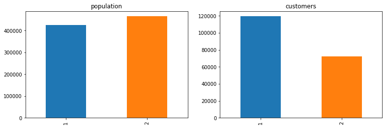

```python
plot_feature_difference('ANREDE_KZ')
```

1 male

2 female

Now, we will compare the estimated household net income between the two groups

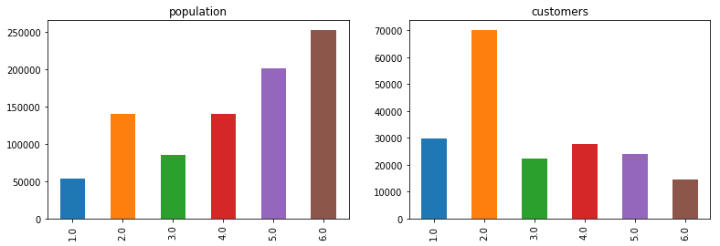

```python
plot_feature_difference('HH_EINKOMMEN_SCORE')
```

1 highest income

2 very high income

3 high income

4 average income

5 lower income

6 very low income

Lastlt, we will compare the number of 1-2 family houses in the two populations

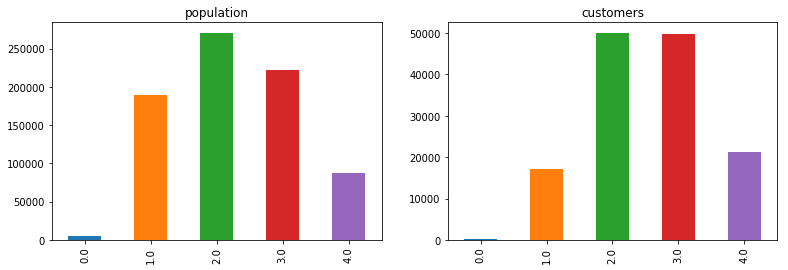

```python
plot_feature_difference('PLZ8_ANTG1')
```

0 none

1 low share

2 average share

3 high share

4 very high share

### Data Preprocessing

Truth ne told, we can't work with all the fearutes in both datasets. For the two population data we have, we are going to reduce the number of features in both dataset to the maximum that we can handle. Reason being that we want to do away with features that will not be included in our analysis, and also to make our analysis straighforward

Filtering the azdias dataset

```python
a = ['ALTERSKATEGORIE_GROB','ANREDE_KZ','CJT_GESAMTTYP','FINANZ_MINIMALIST','FINANZ_SPARER','FINANZ_VORSORGER','FINANZ_ANLEGER','FINANZ_UNAUFFAELLIGER','FINANZ_HAUSBAUER','FINANZTYP','GFK_URLAUBERTYP','GREEN_AVANTGARDE',
 'HEALTH_TYP', 'LP_LEBENSPHASE_FEIN', 'LP_LEBENSPHASE_GROB','LP_FAMILIE_FEIN','LP_FAMILIE_GROB', 'LP_STATUS_FEIN', 'LP_STATUS_GROB', 'NATIONALITAET_KZ', 'PRAEGENDE_JUGENDJAHRE', 'RETOURTYP_BK_S', 'SEMIO_SOZ',
 'SEMIO_FAM','SEMIO_REL','SEMIO_MAT','SEMIO_VERT','SEMIO_LUST','SEMIO_ERL','SEMIO_KULT','SEMIO_RAT','SEMIO_KRIT','SEMIO_DOM', 'SEMIO_KAEM', 'SEMIO_PFLICHT','SEMIO_TRADV','SHOPPER_TYP','SOHO_KZ',
 'VERS_TYP','ZABEOTYP','ANZ_PERSONEN','ANZ_TITEL','HH_EINKOMMEN_SCORE','KK_KUNDENTYP','W_KEIT_KIND_HH','WOHNDAUER_2008','ANZ_HAUSHALTE_AKTIV','ANZ_HH_TITEL','GEBAEUDETYP','KONSUMNAEHE','MIN_GEBAEUDEJAHR','OST_WEST_KZ','WOHNLAGE','CAMEO_DEUG_2015','CAMEO_DEU_2015','CAMEO_INTL_2015','KBA05_ANTG1',
 'KBA05_ANTG2','KBA05_ANTG3','KBA05_ANTG4','KBA05_GBZ','BALLRAUM','EWDICHTE','INNENSTADT','GEBAEUDETYP_RASTER','KKK','MOBI_REGIO','ONLINE_AFFINITAET','REGIOTYP','KBA13_ANZAHL_PKW','PLZ8_ANTG1','PLZ8_ANTG2','PLZ8_ANTG3','PLZ8_ANTG4','PLZ8_BAUMAX','PLZ8_HHZ','PLZ8_GBZ','ARBEIT','ORTSGR_KLS9','RELAT_AB']
```

```python
azdias=azdias1[azdias1.columns[azdias1.columns.isin(a)]]
```

```python
azdias.head()
```

|  | ANZ_HAUSHALTE_AKTIV | ANZ_HH_TITEL | ANZ_PERSONEN | ANZ_TITEL | ARBEIT | BALLRAUM | CAMEO_DEU_2015 | CAMEO_DEUG_2015 | CAMEO_INTL_2015 | CJT_GESAMTTYP | ... | SEMIO_VERT | SHOPPER_TYP | SOHO_KZ | VERS_TYP | W_KEIT_KIND_HH | WOHNDAUER_2008 | WOHNLAGE | ZABEOTYP | ANREDE_KZ | ALTERSKATEGORIE_GROB |
| --- | --- | --- | --- | --- | --- | --- | --- | --- | --- | --- | --- | --- | --- | --- | --- | --- | --- | --- | --- | --- | --- |
| 0 | NaN | NaN | NaN | NaN | NaN | NaN | NaN | NaN | NaN | 2.0 | ... | 1 | -1 | NaN | -1 | NaN | NaN | NaN | 3 | 1 | 2 |
| 1 | 11.0 | 0.0 | 2.0 | 0.0 | 3.0 | 6.0 | 8A | 8 | 51 | 5.0 | ... | 1 | 3 | 1.0 | 2 | 3.0 | 9.0 | 4.0 | 5 | 2 | 1 |
| 2 | 10.0 | 0.0 | 1.0 | 0.0 | 3.0 | 2.0 | 4C | 4 | 24 | 3.0 | ... | 4 | 2 | 0.0 | 1 | 3.0 | 9.0 | 2.0 | 5 | 2 | 3 |
| 3 | 1.0 | 0.0 | 0.0 | 0.0 | 2.0 | 4.0 | 2A | 2 | 12 | 2.0 | ... | 4 | 1 | 0.0 | 1 | NaN | 9.0 | 7.0 | 3 | 2 | 4 |
| 4 | 3.0 | 0.0 | 4.0 | 0.0 | 4.0 | 2.0 | 6B | 6 | 43 | 5.0 | ... | 7 | 2 | 0.0 | 2 | 2.0 | 9.0 | 3.0 | 4 | 1 | 3 |

5 rows × 80 columns

```python
azdias.shape
```

```
(891221, 80)
```

```python
customers=customers1[customers1.columns[customers1.columns.isin(a)]]
```

```python
customers.head()
```

|  | ANZ_HAUSHALTE_AKTIV | ANZ_HH_TITEL | ANZ_PERSONEN | ANZ_TITEL | ARBEIT | BALLRAUM | CAMEO_DEU_2015 | CAMEO_DEUG_2015 | CAMEO_INTL_2015 | CJT_GESAMTTYP | ... | SEMIO_VERT | SHOPPER_TYP | SOHO_KZ | VERS_TYP | W_KEIT_KIND_HH | WOHNDAUER_2008 | WOHNLAGE | ZABEOTYP | ANREDE_KZ | ALTERSKATEGORIE_GROB |
| --- | --- | --- | --- | --- | --- | --- | --- | --- | --- | --- | --- | --- | --- | --- | --- | --- | --- | --- | --- | --- | --- |
| 0 | 1.0 | 0.0 | 2.0 | 0.0 | 1.0 | 3.0 | 1A | 1 | 13 | 5.0 | ... | 6 | 3 | 0.0 | 1 | 6.0 | 9.0 | 7.0 | 3 | 1 | 4 |
| 1 | NaN | NaN | 3.0 | 0.0 | NaN | NaN | NaN | NaN | NaN | NaN | ... | 7 | 3 | 0.0 | 1 | 0.0 | 9.0 | NaN | 3 | 1 | 4 |
| 2 | 1.0 | 0.0 | 1.0 | 0.0 | 3.0 | 7.0 | 5D | 5 | 34 | 2.0 | ... | 3 | 1 | 0.0 | 2 | 6.0 | 9.0 | 2.0 | 3 | 2 | 4 |
| 3 | 0.0 | NaN | 0.0 | 0.0 | 1.0 | 7.0 | 4C | 4 | 24 | 2.0 | ... | 7 | 0 | 0.0 | 1 | NaN | 9.0 | 7.0 | 1 | 1 | 4 |
| 4 | 7.0 | 0.0 | 4.0 | 0.0 | 3.0 | 3.0 | 7B | 7 | 41 | 6.0 | ... | 5 | 1 | 0.0 | 2 | 2.0 | 9.0 | 3.0 | 1 | 1 | 3 |

5 rows × 80 columns

```python
customers.shape
```

```
(191652, 80)
```

### Dealing with missing values/nulls

Let us see the number of nulls we have in each dataset

```python
azdias.isnull().sum().sum()
```

```
4616516
```

```python
customers.isnull().sum().sum()
```

```
2103102
```

```python
azdias.info()
```

```
<class 'pandas.core.frame.DataFrame'>
RangeIndex: 891221 entries, 0 to 891220
Data columns (total 80 columns):
ANZ_HAUSHALTE_AKTIV      798073 non-null float64
ANZ_HH_TITEL             794213 non-null float64
ANZ_PERSONEN             817722 non-null float64
ANZ_TITEL                817722 non-null float64
ARBEIT                   794005 non-null float64
BALLRAUM                 797481 non-null float64
CAMEO_DEU_2015           792242 non-null object
CAMEO_DEUG_2015          792242 non-null object
CAMEO_INTL_2015          792242 non-null object
CJT_GESAMTTYP            886367 non-null float64
EWDICHTE                 797481 non-null float64
FINANZ_ANLEGER           891221 non-null int64
FINANZ_HAUSBAUER         891221 non-null int64
FINANZ_MINIMALIST        891221 non-null int64
FINANZ_SPARER            891221 non-null int64
FINANZ_UNAUFFAELLIGER    891221 non-null int64
FINANZ_VORSORGER         891221 non-null int64
FINANZTYP                891221 non-null int64
GEBAEUDETYP              798073 non-null float64
GEBAEUDETYP_RASTER       798066 non-null float64
GFK_URLAUBERTYP          886367 non-null float64
GREEN_AVANTGARDE         891221 non-null int64
HEALTH_TYP               891221 non-null int64
HH_EINKOMMEN_SCORE       872873 non-null float64
INNENSTADT               797481 non-null float64
KBA05_ANTG1              757897 non-null float64
KBA05_ANTG2              757897 non-null float64
KBA05_ANTG3              757897 non-null float64
KBA05_ANTG4              757897 non-null float64
KBA05_GBZ                757897 non-null float64
KBA13_ANZAHL_PKW         785421 non-null float64
KK_KUNDENTYP             306609 non-null float64
KKK                      770025 non-null float64
KONSUMNAEHE              817252 non-null float64
LP_FAMILIE_FEIN          886367 non-null float64
LP_FAMILIE_GROB          886367 non-null float64
LP_LEBENSPHASE_FEIN      886367 non-null float64
```

[output cut: 30 more lines]

```
SEMIO_REL                891221 non-null int64
SEMIO_SOZ                891221 non-null int64
SEMIO_TRADV              891221 non-null int64
SEMIO_VERT               891221 non-null int64
SHOPPER_TYP              891221 non-null int64
SOHO_KZ                  817722 non-null float64
VERS_TYP                 891221 non-null int64
W_KEIT_KIND_HH           783619 non-null float64
WOHNDAUER_2008           817722 non-null float64
WOHNLAGE                 798073 non-null float64
ZABEOTYP                 891221 non-null int64
ANREDE_KZ                891221 non-null int64
ALTERSKATEGORIE_GROB     891221 non-null int64
dtypes: float64(46), int64(30), object(4)
memory usage: 544.0+ MB
```

```python
#  We will perform an assessment of how much missing data there is in each column of the
# dataset.
azdias1=azdias.isna().sum()
azdias1
```

```
ANZ_HAUSHALTE_AKTIV       93148
ANZ_HH_TITEL              97008
ANZ_PERSONEN              73499
ANZ_TITEL                 73499
ARBEIT                    97216
BALLRAUM                  93740
CAMEO_DEU_2015            98979
CAMEO_DEUG_2015           98979
CAMEO_INTL_2015           98979
CJT_GESAMTTYP              4854
EWDICHTE                  93740
FINANZ_ANLEGER                0
FINANZ_HAUSBAUER              0
FINANZ_MINIMALIST             0
FINANZ_SPARER                 0
FINANZ_UNAUFFAELLIGER         0
FINANZ_VORSORGER              0
FINANZTYP                     0
GEBAEUDETYP               93148
GEBAEUDETYP_RASTER        93155
GFK_URLAUBERTYP            4854
GREEN_AVANTGARDE              0
HEALTH_TYP                    0
HH_EINKOMMEN_SCORE        18348
INNENSTADT                93740
KBA05_ANTG1              133324
KBA05_ANTG2              133324
KBA05_ANTG3              133324
KBA05_ANTG4              133324
KBA05_GBZ                133324
KBA13_ANZAHL_PKW         105800
KK_KUNDENTYP             584612
KKK                      121196
KONSUMNAEHE               73969
LP_FAMILIE_FEIN            4854
LP_FAMILIE_GROB            4854
LP_LEBENSPHASE_FEIN        4854
LP_LEBENSPHASE_GROB        4854
LP_STATUS_FEIN             4854
LP_STATUS_GROB             4854
```

[output cut: 26 more lines]

```
SEMIO_RAT                     0
SEMIO_REL                     0
SEMIO_SOZ                     0
SEMIO_TRADV                   0
SEMIO_VERT                    0
SHOPPER_TYP                   0
SOHO_KZ                   73499
VERS_TYP                      0
W_KEIT_KIND_HH           107602
WOHNDAUER_2008            73499
WOHNLAGE                  93148
ZABEOTYP                      0
ANREDE_KZ                     0
ALTERSKATEGORIE_GROB          0
dtype: int64
```

Now, let us obtain the proportion of NaNs per column

```python
len(azdias)
```

```
891221
```

```python
azdias2= azdias.isna().sum()/891221*100
azdias2
```

```
ANZ_HAUSHALTE_AKTIV      10.451729
ANZ_HH_TITEL             10.884842
ANZ_PERSONEN              8.247000
ANZ_TITEL                 8.247000
ARBEIT                   10.908181
BALLRAUM                 10.518154
CAMEO_DEU_2015           11.106000
CAMEO_DEUG_2015          11.106000
CAMEO_INTL_2015          11.106000
CJT_GESAMTTYP             0.544646
EWDICHTE                 10.518154
FINANZ_ANLEGER            0.000000
FINANZ_HAUSBAUER          0.000000
FINANZ_MINIMALIST         0.000000
FINANZ_SPARER             0.000000
FINANZ_UNAUFFAELLIGER     0.000000
FINANZ_VORSORGER          0.000000
FINANZTYP                 0.000000
GEBAEUDETYP              10.451729
GEBAEUDETYP_RASTER       10.452514
GFK_URLAUBERTYP           0.544646
GREEN_AVANTGARDE          0.000000
HEALTH_TYP                0.000000
HH_EINKOMMEN_SCORE        2.058749
INNENSTADT               10.518154
KBA05_ANTG1              14.959701
KBA05_ANTG2              14.959701
KBA05_ANTG3              14.959701
KBA05_ANTG4              14.959701
KBA05_GBZ                14.959701
KBA13_ANZAHL_PKW         11.871354
KK_KUNDENTYP             65.596749
KKK                      13.598872
KONSUMNAEHE               8.299737
LP_FAMILIE_FEIN           0.544646
LP_FAMILIE_GROB           0.544646
LP_LEBENSPHASE_FEIN       0.544646
LP_LEBENSPHASE_GROB       0.544646
LP_STATUS_FEIN            0.544646
LP_STATUS_GROB            0.544646
```

[output cut: 26 more lines]

```
SEMIO_RAT                 0.000000
SEMIO_REL                 0.000000
SEMIO_SOZ                 0.000000
SEMIO_TRADV               0.000000
SEMIO_VERT                0.000000
SHOPPER_TYP               0.000000
SOHO_KZ                   8.247000
VERS_TYP                  0.000000
W_KEIT_KIND_HH           12.073549
WOHNDAUER_2008            8.247000
WOHNLAGE                 10.451729
ZABEOTYP                  0.000000
ANREDE_KZ                 0.000000
ALTERSKATEGORIE_GROB      0.000000
dtype: float64
```

We will now plot the proportion of NaNs in each column in azdias dataset on an histogram

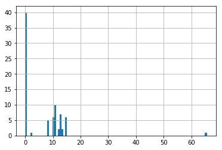

```python
# Investigate patterns in the amount of missing data in each column.
azdias2.hist(bins=100)
```

```python
# We will remove the outlier columns from the dataset.
#Setting 20 as the maximum proportion of missing values per column
azdais3 = azdias2[azdias2 > 20.0]
azdais4  = azdais3.index.tolist()
azdais4
```

```
['KK_KUNDENTYP']
```

Only one column above will be treated as an outlier; having a proportion of NaNs greater than 20

```python
new_azdias = azdias.drop(azdais4, axis =1)
new_azdias
```

|  | ANZ_HAUSHALTE_AKTIV | ANZ_HH_TITEL | ANZ_PERSONEN | ANZ_TITEL | ARBEIT | BALLRAUM | CAMEO_DEU_2015 | CAMEO_DEUG_2015 | CAMEO_INTL_2015 | CJT_GESAMTTYP | ... | SEMIO_VERT | SHOPPER_TYP | SOHO_KZ | VERS_TYP | W_KEIT_KIND_HH | WOHNDAUER_2008 | WOHNLAGE | ZABEOTYP | ANREDE_KZ | ALTERSKATEGORIE_GROB |
| --- | --- | --- | --- | --- | --- | --- | --- | --- | --- | --- | --- | --- | --- | --- | --- | --- | --- | --- | --- | --- | --- |
| 0 | NaN | NaN | NaN | NaN | NaN | NaN | NaN | NaN | NaN | 2.0 | ... | 1 | -1 | NaN | -1 | NaN | NaN | NaN | 3 | 1 | 2 |
| 1 | 11.0 | 0.0 | 2.0 | 0.0 | 3.0 | 6.0 | 8A | 8 | 51 | 5.0 | ... | 1 | 3 | 1.0 | 2 | 3.0 | 9.0 | 4.0 | 5 | 2 | 1 |
| 2 | 10.0 | 0.0 | 1.0 | 0.0 | 3.0 | 2.0 | 4C | 4 | 24 | 3.0 | ... | 4 | 2 | 0.0 | 1 | 3.0 | 9.0 | 2.0 | 5 | 2 | 3 |
| 3 | 1.0 | 0.0 | 0.0 | 0.0 | 2.0 | 4.0 | 2A | 2 | 12 | 2.0 | ... | 4 | 1 | 0.0 | 1 | NaN | 9.0 | 7.0 | 3 | 2 | 4 |
| 4 | 3.0 | 0.0 | 4.0 | 0.0 | 4.0 | 2.0 | 6B | 6 | 43 | 5.0 | ... | 7 | 2 | 0.0 | 2 | 2.0 | 9.0 | 3.0 | 4 | 1 | 3 |
| 5 | 5.0 | 0.0 | 1.0 | 0.0 | 2.0 | 6.0 | 8C | 8 | 54 | 2.0 | ... | 2 | 0 | 0.0 | 2 | 6.0 | 9.0 | 7.0 | 4 | 2 | 1 |
| 6 | 4.0 | 0.0 | 1.0 | 0.0 | 4.0 | 6.0 | 4A | 4 | 22 | 5.0 | ... | 2 | 1 | 0.0 | 1 | 3.0 | 9.0 | 5.0 | 4 | 2 | 2 |
| 7 | 6.0 | 0.0 | 1.0 | 0.0 | 2.0 | 2.0 | 2D | 2 | 14 | 3.0 | ... | 6 | 0 | 0.0 | 1 | 5.0 | 9.0 | 1.0 | 1 | 1 | 1 |
| 8 | 2.0 | 1.0 | 1.0 | 0.0 | 2.0 | 3.0 | 1A | 1 | 13 | 3.0 | ... | 5 | 3 | 0.0 | 2 | 5.0 | 8.0 | 1.0 | 6 | 1 | 3 |
| 9 | 9.0 | 0.0 | 1.0 | 0.0 | 2.0 | 6.0 | 1E | 1 | 15 | 4.0 | ... | 2 | 3 | 0.0 | 2 | 4.0 | 3.0 | 7.0 | 4 | 2 | 3 |
| 10 | 6.0 | 0.0 | 1.0 | 0.0 | 4.0 | 6.0 | 9D | 9 | 51 | 1.0 | ... | 5 | 2 | 0.0 | 2 | 6.0 | 9.0 | 5.0 | 3 | 2 | 3 |
| 11 | NaN | NaN | NaN | NaN | NaN | NaN | NaN | NaN | NaN | 6.0 | ... | 1 | -1 | NaN | -1 | NaN | NaN | NaN | 3 | 1 | 2 |
| 12 | 1.0 | 0.0 | 2.0 | 0.0 | 3.0 | 2.0 | 6B | 6 | 43 | 6.0 | ... | 7 | 1 | 0.0 | 1 | 6.0 | 4.0 | 3.0 | 1 | 1 | 3 |
| 13 | 2.0 | 0.0 | 1.0 | 0.0 | 3.0 | 7.0 | 5C | 5 | 33 | 5.0 | ... | 1 | 3 | 0.0 | 2 | 6.0 | 3.0 | 5.0 | 5 | 2 | 1 |
| 14 | NaN | NaN | NaN | NaN | NaN | NaN | NaN | NaN | NaN | 6.0 | ... | 1 | -1 | NaN | -1 | NaN | NaN | NaN | 3 | 1 | 3 |
| 15 | 1.0 | 0.0 | 1.0 | 0.0 | 4.0 | 1.0 | 8B | 8 | 41 | 4.0 | ... | 2 | 1 | 0.0 | 2 | 6.0 | 4.0 | 3.0 | 3 | 2 | 4 |
| 16 | 0.0 | 0.0 | 0.0 | 0.0 | 1.0 | 6.0 | 7A | 7 | 41 | 1.0 | ... | 2 | 2 | 0.0 | 2 | NaN | 3.0 | 7.0 | 5 | 2 | 1 |
| 17 | NaN | NaN | NaN | NaN | NaN | NaN | NaN | NaN | NaN | 6.0 | ... | 1 | -1 | NaN | -1 | NaN | NaN | NaN | 3 | 1 | 2 |
| 18 | 2.0 | 0.0 | 1.0 | 0.0 | 3.0 | 6.0 | 4C | 4 | 24 | 6.0 | ... | 4 | 1 | 0.0 | 1 | 0.0 | 5.0 | 2.0 | 4 | 2 | 2 |
| 19 | 1.0 | 0.0 | 2.0 | 0.0 | 4.0 | 6.0 | 5D | 5 | 34 | 3.0 | ... | 7 | 2 | 0.0 | 2 | 5.0 | 6.0 | 1.0 | 2 | 1 | 3 |
| 20 | 1.0 | 0.0 | 1.0 | 0.0 | 3.0 | 5.0 | 4C | 4 | 24 | 4.0 | ... | 2 | 1 | 0.0 | 1 | 3.0 | 4.0 | 5.0 | 3 | 2 | 2 |
| 21 | 2.0 | 0.0 | 1.0 | 0.0 | 5.0 | 2.0 | 9E | 9 | 55 | 3.0 | ... | 7 | 1 | 0.0 | 2 | 5.0 | 9.0 | 4.0 | 4 | 1 | 2 |
| 22 | 14.0 | 0.0 | 1.0 | 0.0 | 4.0 | 3.0 | 9D | 9 | 51 | 4.0 | ... | 6 | 1 | 0.0 | 2 | 6.0 | 4.0 | 4.0 | 4 | 1 | 1 |
| 23 | 1.0 | 0.0 | 2.0 | 0.0 | 3.0 | 2.0 | 6B | 6 | 43 | 3.0 | ... | 5 | 0 | 0.0 | 2 | 3.0 | 2.0 | 3.0 | 4 | 1 | 3 |
| 24 | NaN | NaN | NaN | NaN | NaN | NaN | NaN | NaN | NaN | 6.0 | ... | 1 | -1 | NaN | -1 | NaN | NaN | NaN | 3 | 2 | 3 |
| 25 | 1.0 | 0.0 | 0.0 | 0.0 | 3.0 | 7.0 | 5C | 5 | 33 | 3.0 | ... | 7 | 0 | 0.0 | 2 | NaN | 3.0 | 7.0 | 5 | 1 | 1 |
| 26 | 1.0 | 0.0 | 1.0 | 0.0 | 4.0 | 7.0 | NaN | NaN | NaN | 3.0 | ... | 7 | 1 | 0.0 | 1 | 3.0 | 3.0 | 7.0 | 1 | 1 | 3 |
| 27 | 6.0 | 0.0 | 2.0 | 0.0 | 4.0 | 1.0 | 9B | 9 | 51 | 4.0 | ... | 5 | 0 | 0.0 | 2 | 1.0 | 3.0 | 3.0 | 4 | 1 | 3 |
| 28 | 3.0 | 0.0 | 1.0 | 0.0 | 3.0 | 4.0 | 1A | 1 | 13 | 2.0 | ... | 7 | 1 | 0.0 | 2 | 5.0 | 8.0 | 5.0 | 6 | 1 | 3 |
| 29 | 1.0 | 0.0 | 1.0 | 0.0 | 2.0 | 5.0 | 2A | 2 | 12 | 1.0 | ... | 4 | 1 | 0.0 | 2 | 6.0 | 8.0 | 3.0 | 1 | 2 | 4 |

[output cut: 471 more lines]

891221 rows × 79 columns

Let us see the number of missing values per row in our dataset

```python
# How much data is missing in each row of the dataset?
azdias5=new_azdias.isnull().sum(axis = 1)
azdias5
```

```
0         38
1          0
2          0
3          1
4          0
5          0
6          0
7          0
8          0
9          0
10         0
11        38
12         6
13         8
14        38
```

[output cut: 487 more lines]

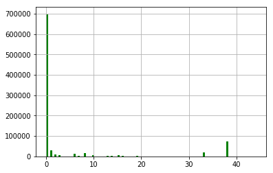

```python
azdias5.hist(bins=100, color = 'green')
```

Let is set our threshold to be 20

```python
# We will write code to divide the data into two subsets based on the number of missing
# values in each row.
azdias6 = new_azdias[azdias5 <= 20]
azdias7 = new_azdias[azdias5 > 20]
azdias6
```

|  | ANZ_HAUSHALTE_AKTIV | ANZ_HH_TITEL | ANZ_PERSONEN | ANZ_TITEL | ARBEIT | BALLRAUM | CAMEO_DEU_2015 | CAMEO_DEUG_2015 | CAMEO_INTL_2015 | CJT_GESAMTTYP | ... | SEMIO_VERT | SHOPPER_TYP | SOHO_KZ | VERS_TYP | W_KEIT_KIND_HH | WOHNDAUER_2008 | WOHNLAGE | ZABEOTYP | ANREDE_KZ | ALTERSKATEGORIE_GROB |
| --- | --- | --- | --- | --- | --- | --- | --- | --- | --- | --- | --- | --- | --- | --- | --- | --- | --- | --- | --- | --- | --- |
| 1 | 11.0 | 0.0 | 2.0 | 0.0 | 3.0 | 6.0 | 8A | 8 | 51 | 5.0 | ... | 1 | 3 | 1.0 | 2 | 3.0 | 9.0 | 4.0 | 5 | 2 | 1 |
| 2 | 10.0 | 0.0 | 1.0 | 0.0 | 3.0 | 2.0 | 4C | 4 | 24 | 3.0 | ... | 4 | 2 | 0.0 | 1 | 3.0 | 9.0 | 2.0 | 5 | 2 | 3 |
| 3 | 1.0 | 0.0 | 0.0 | 0.0 | 2.0 | 4.0 | 2A | 2 | 12 | 2.0 | ... | 4 | 1 | 0.0 | 1 | NaN | 9.0 | 7.0 | 3 | 2 | 4 |
| 4 | 3.0 | 0.0 | 4.0 | 0.0 | 4.0 | 2.0 | 6B | 6 | 43 | 5.0 | ... | 7 | 2 | 0.0 | 2 | 2.0 | 9.0 | 3.0 | 4 | 1 | 3 |
| 5 | 5.0 | 0.0 | 1.0 | 0.0 | 2.0 | 6.0 | 8C | 8 | 54 | 2.0 | ... | 2 | 0 | 0.0 | 2 | 6.0 | 9.0 | 7.0 | 4 | 2 | 1 |
| 6 | 4.0 | 0.0 | 1.0 | 0.0 | 4.0 | 6.0 | 4A | 4 | 22 | 5.0 | ... | 2 | 1 | 0.0 | 1 | 3.0 | 9.0 | 5.0 | 4 | 2 | 2 |
| 7 | 6.0 | 0.0 | 1.0 | 0.0 | 2.0 | 2.0 | 2D | 2 | 14 | 3.0 | ... | 6 | 0 | 0.0 | 1 | 5.0 | 9.0 | 1.0 | 1 | 1 | 1 |
| 8 | 2.0 | 1.0 | 1.0 | 0.0 | 2.0 | 3.0 | 1A | 1 | 13 | 3.0 | ... | 5 | 3 | 0.0 | 2 | 5.0 | 8.0 | 1.0 | 6 | 1 | 3 |
| 9 | 9.0 | 0.0 | 1.0 | 0.0 | 2.0 | 6.0 | 1E | 1 | 15 | 4.0 | ... | 2 | 3 | 0.0 | 2 | 4.0 | 3.0 | 7.0 | 4 | 2 | 3 |
| 10 | 6.0 | 0.0 | 1.0 | 0.0 | 4.0 | 6.0 | 9D | 9 | 51 | 1.0 | ... | 5 | 2 | 0.0 | 2 | 6.0 | 9.0 | 5.0 | 3 | 2 | 3 |
| 12 | 1.0 | 0.0 | 2.0 | 0.0 | 3.0 | 2.0 | 6B | 6 | 43 | 6.0 | ... | 7 | 1 | 0.0 | 1 | 6.0 | 4.0 | 3.0 | 1 | 1 | 3 |
| 13 | 2.0 | 0.0 | 1.0 | 0.0 | 3.0 | 7.0 | 5C | 5 | 33 | 5.0 | ... | 1 | 3 | 0.0 | 2 | 6.0 | 3.0 | 5.0 | 5 | 2 | 1 |
| 15 | 1.0 | 0.0 | 1.0 | 0.0 | 4.0 | 1.0 | 8B | 8 | 41 | 4.0 | ... | 2 | 1 | 0.0 | 2 | 6.0 | 4.0 | 3.0 | 3 | 2 | 4 |
| 16 | 0.0 | 0.0 | 0.0 | 0.0 | 1.0 | 6.0 | 7A | 7 | 41 | 1.0 | ... | 2 | 2 | 0.0 | 2 | NaN | 3.0 | 7.0 | 5 | 2 | 1 |
| 18 | 2.0 | 0.0 | 1.0 | 0.0 | 3.0 | 6.0 | 4C | 4 | 24 | 6.0 | ... | 4 | 1 | 0.0 | 1 | 0.0 | 5.0 | 2.0 | 4 | 2 | 2 |
| 19 | 1.0 | 0.0 | 2.0 | 0.0 | 4.0 | 6.0 | 5D | 5 | 34 | 3.0 | ... | 7 | 2 | 0.0 | 2 | 5.0 | 6.0 | 1.0 | 2 | 1 | 3 |
| 20 | 1.0 | 0.0 | 1.0 | 0.0 | 3.0 | 5.0 | 4C | 4 | 24 | 4.0 | ... | 2 | 1 | 0.0 | 1 | 3.0 | 4.0 | 5.0 | 3 | 2 | 2 |
| 21 | 2.0 | 0.0 | 1.0 | 0.0 | 5.0 | 2.0 | 9E | 9 | 55 | 3.0 | ... | 7 | 1 | 0.0 | 2 | 5.0 | 9.0 | 4.0 | 4 | 1 | 2 |
| 22 | 14.0 | 0.0 | 1.0 | 0.0 | 4.0 | 3.0 | 9D | 9 | 51 | 4.0 | ... | 6 | 1 | 0.0 | 2 | 6.0 | 4.0 | 4.0 | 4 | 1 | 1 |
| 23 | 1.0 | 0.0 | 2.0 | 0.0 | 3.0 | 2.0 | 6B | 6 | 43 | 3.0 | ... | 5 | 0 | 0.0 | 2 | 3.0 | 2.0 | 3.0 | 4 | 1 | 3 |
| 25 | 1.0 | 0.0 | 0.0 | 0.0 | 3.0 | 7.0 | 5C | 5 | 33 | 3.0 | ... | 7 | 0 | 0.0 | 2 | NaN | 3.0 | 7.0 | 5 | 1 | 1 |
| 26 | 1.0 | 0.0 | 1.0 | 0.0 | 4.0 | 7.0 | NaN | NaN | NaN | 3.0 | ... | 7 | 1 | 0.0 | 1 | 3.0 | 3.0 | 7.0 | 1 | 1 | 3 |
| 27 | 6.0 | 0.0 | 2.0 | 0.0 | 4.0 | 1.0 | 9B | 9 | 51 | 4.0 | ... | 5 | 0 | 0.0 | 2 | 1.0 | 3.0 | 3.0 | 4 | 1 | 3 |
| 28 | 3.0 | 0.0 | 1.0 | 0.0 | 3.0 | 4.0 | 1A | 1 | 13 | 2.0 | ... | 7 | 1 | 0.0 | 2 | 5.0 | 8.0 | 5.0 | 6 | 1 | 3 |
| 29 | 1.0 | 0.0 | 1.0 | 0.0 | 2.0 | 5.0 | 2A | 2 | 12 | 1.0 | ... | 4 | 1 | 0.0 | 2 | 6.0 | 8.0 | 3.0 | 1 | 2 | 4 |
| 31 | 11.0 | 0.0 | 1.0 | 0.0 | 4.0 | 1.0 | 9D | 9 | 51 | 6.0 | ... | 3 | 1 | 0.0 | 1 | 6.0 | 9.0 | 2.0 | 4 | 2 | 2 |
| 32 | 1.0 | 0.0 | 2.0 | 0.0 | 4.0 | 6.0 | 1B | 1 | 14 | 4.0 | ... | 6 | 0 | 0.0 | 1 | 6.0 | 9.0 | 7.0 | 1 | 1 | 1 |
| 33 | 3.0 | 0.0 | 4.0 | 0.0 | 3.0 | 1.0 | 8B | 8 | 41 | 4.0 | ... | 2 | 1 | 0.0 | 2 | 4.0 | 9.0 | 1.0 | 3 | 2 | 2 |
| 34 | 1.0 | 0.0 | 1.0 | 0.0 | 4.0 | 1.0 | 3D | 3 | 25 | 2.0 | ... | 1 | -1 | 0.0 | -1 | 6.0 | 5.0 | 3.0 | 1 | 2 | 1 |
| 36 | 13.0 | 0.0 | 1.0 | 0.0 | 4.0 | 1.0 | 7A | 7 | 41 | 2.0 | ... | 2 | 2 | 0.0 | 2 | 3.0 | 9.0 | 3.0 | 3 | 2 | 3 |

[output cut: 471 more lines]

797920 rows × 79 columns

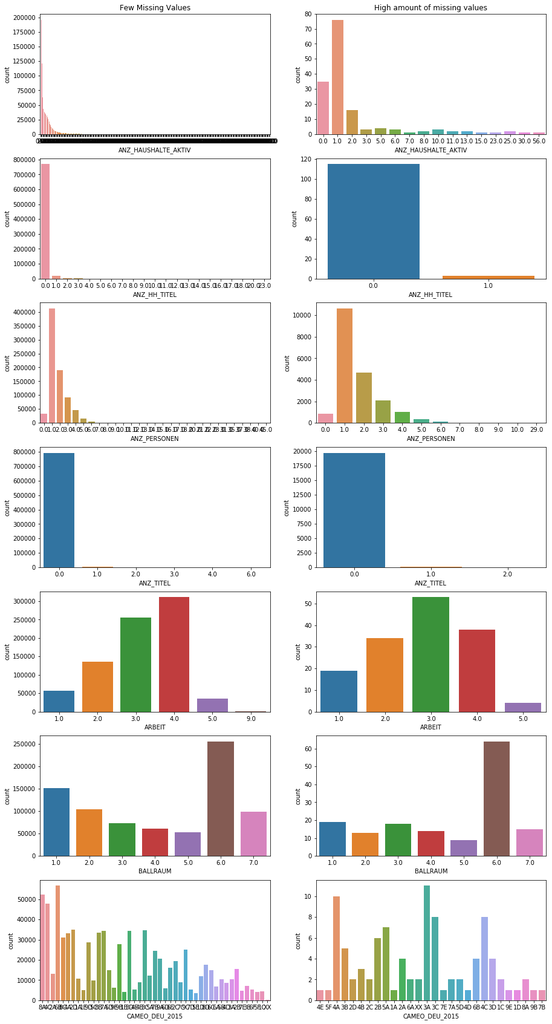

```python
# Let is compare the distribution of values for at least five columns where there are
# no or few missing values, between the two subsets.
fig, axes = plt.subplots(nrows=7, ncols=2, figsize=(15,30), squeeze=False)
n=0
for columns in new_azdias.columns[:7]:
    sns.countplot(x=columns, data=azdias6, ax=axes[n,0])
    axes[0][0].set_title('Few Missing Values')
    sns.countplot(x=columns, data=azdias7, ax=axes[n,1])
    axes[0][1].set_title('High amount of missing values')
    n+=1
```

### Re-Encoding Features

```python
azdias6.info()
```

```
<class 'pandas.core.frame.DataFrame'>
Int64Index: 797920 entries, 1 to 891220
Data columns (total 79 columns):
ANZ_HAUSHALTE_AKTIV      797920 non-null float64
ANZ_HH_TITEL             794095 non-null float64
ANZ_PERSONEN             797920 non-null float64
ANZ_TITEL                797920 non-null float64
ARBEIT                   793857 non-null float64
BALLRAUM                 797329 non-null float64
CAMEO_DEU_2015           792147 non-null object
CAMEO_DEUG_2015          792147 non-null object
CAMEO_INTL_2015          792147 non-null object
CJT_GESAMTTYP            793278 non-null float64
EWDICHTE                 797329 non-null float64
FINANZ_ANLEGER           797920 non-null int64
FINANZ_HAUSBAUER         797920 non-null int64
FINANZ_MINIMALIST        797920 non-null int64
FINANZ_SPARER            797920 non-null int64
FINANZ_UNAUFFAELLIGER    797920 non-null int64
FINANZ_VORSORGER         797920 non-null int64
FINANZTYP                797920 non-null int64
GEBAEUDETYP              797920 non-null float64
GEBAEUDETYP_RASTER       797915 non-null float64
GFK_URLAUBERTYP          793278 non-null float64
GREEN_AVANTGARDE         797920 non-null int64
HEALTH_TYP               797920 non-null int64
HH_EINKOMMEN_SCORE       797920 non-null float64
INNENSTADT               797329 non-null float64
KBA05_ANTG1              757895 non-null float64
KBA05_ANTG2              757895 non-null float64
KBA05_ANTG3              757895 non-null float64
KBA05_ANTG4              757895 non-null float64
KBA05_GBZ                757895 non-null float64
KBA13_ANZAHL_PKW         785357 non-null float64
KKK                      769979 non-null float64
KONSUMNAEHE              797851 non-null float64
LP_FAMILIE_FEIN          793278 non-null float64
LP_FAMILIE_GROB          793278 non-null float64
LP_LEBENSPHASE_FEIN      793278 non-null float64
LP_LEBENSPHASE_GROB      793278 non-null float64
```

[output cut: 29 more lines]

```
SEMIO_REL                797920 non-null int64
SEMIO_SOZ                797920 non-null int64
SEMIO_TRADV              797920 non-null int64
SEMIO_VERT               797920 non-null int64
SHOPPER_TYP              797920 non-null int64
SOHO_KZ                  797920 non-null float64
VERS_TYP                 797920 non-null int64
W_KEIT_KIND_HH           764661 non-null float64
WOHNDAUER_2008           797920 non-null float64
WOHNLAGE                 797920 non-null float64
ZABEOTYP                 797920 non-null int64
ANREDE_KZ                797920 non-null int64
ALTERSKATEGORIE_GROB     797920 non-null int64
dtypes: float64(45), int64(30), object(4)
memory usage: 507.0+ MB
```

Re-encoding OST_WEST_KZ

```python
azdias6['OST_WEST_KZ'].value_counts()
```

```
W    629401
O    168519
Name: OST_WEST_KZ, dtype: int64
```

Clearly, this attribute has non-numeric values. Therefore, we will replace the 'W' and 'O' with 0 and 1 respectively

```python
new_values = {'W': 0, 'O': 1}
azdias6 = azdias6.replace({'OST_WEST_KZ':new_values})
```

```python
azdias6['OST_WEST_KZ'].value_counts()
```

```
0    629401
1    168519
Name: OST_WEST_KZ, dtype: int64
```

Now, it is done. Great!!!

Re-encoding CAMEO_INTL_2015

We will need to convert the the 'CAMEO_INTL_2015' to numeric

```python
azdias6['CAMEO_INTL_2015'] = pd.to_numeric(azdias6['CAMEO_INTL_2015'], errors = 'coercion')
```

```python
Wealth= []
Life_Stage=[]
for values in azdias6["CAMEO_INTL_2015"]:
#Maping for Wealthy
    if values in [11,12,13,14,15]:
        Wealth.append(5.0)
    elif values in [21,22,23,24,25]:
        Wealth.append(4.0)
    elif values in [31,32,33,34,35]:
        Wealth.append(3.0)
    elif values in [41,42,43,44,45]:
        Wealth.append(2.0)
    elif values in [51,52,53, 54, 55]:
        Wealth.append(1.0)
    else:
        Wealth.append(np.nan)
    #Maping Life Stage

    if values in [11,21,31,41,51]:
        Life_Stage.append(1.0)
    elif values in [12,22,32,42,52]:
        Life_Stage.append(2.0)
    elif values in [13,23,33,43,53]:
        Life_Stage.append(3.0)
    elif values in [14,24,34,44,54]:
        Life_Stage.append(4.0)
    elif values in [15,25,35,45,55]:
        Life_Stage.append(5.0)
    else:
        Life_Stage.append(np.nan)
```

Let us create another column called "CAMEO_INTL_2015_Life_Stage"

```python
azdias6["CAMEO_INTL_2015_LIFE_STAGE"] = Life_Stage
```

We will create another column named "CAMEO_INTL_2015_Wealth"

```python
azdias6["CAMEO_INTL_2015_WEALTH"] = Wealth
```

Now, we will drop the 'CAMEO_INTL_2015'

```python
azdias6 = azdias6.drop('CAMEO_INTL_2015', axis =1)
```

```python
azdias6 = azdias6.drop(['CAMEO_DEU_2015','CAMEO_DEUG_2015'], axis =1)
```

```python
azdias_new =azdias6
azdias_new
```

|  | ANZ_HAUSHALTE_AKTIV | ANZ_HH_TITEL | ANZ_PERSONEN | ANZ_TITEL | ARBEIT | BALLRAUM | CJT_GESAMTTYP | EWDICHTE | FINANZ_ANLEGER | FINANZ_HAUSBAUER | ... | SOHO_KZ | VERS_TYP | W_KEIT_KIND_HH | WOHNDAUER_2008 | WOHNLAGE | ZABEOTYP | ANREDE_KZ | ALTERSKATEGORIE_GROB | CAMEO_INTL_2015_LIFE_STAGE | CAMEO_INTL_2015_WEALTH |
| --- | --- | --- | --- | --- | --- | --- | --- | --- | --- | --- | --- | --- | --- | --- | --- | --- | --- | --- | --- | --- | --- |
| 1 | 11.0 | 0.0 | 2.0 | 0.0 | 3.0 | 6.0 | 5.0 | 3.0 | 5 | 5 | ... | 1.0 | 2 | 3.0 | 9.0 | 4.0 | 5 | 2 | 1 | 1.0 | 1.0 |
| 2 | 10.0 | 0.0 | 1.0 | 0.0 | 3.0 | 2.0 | 3.0 | 4.0 | 2 | 5 | ... | 0.0 | 1 | 3.0 | 9.0 | 2.0 | 5 | 2 | 3 | 4.0 | 4.0 |
| 3 | 1.0 | 0.0 | 0.0 | 0.0 | 2.0 | 4.0 | 2.0 | 2.0 | 2 | 2 | ... | 0.0 | 1 | NaN | 9.0 | 7.0 | 3 | 2 | 4 | 2.0 | 5.0 |
| 4 | 3.0 | 0.0 | 4.0 | 0.0 | 4.0 | 2.0 | 5.0 | 5.0 | 1 | 2 | ... | 0.0 | 2 | 2.0 | 9.0 | 3.0 | 4 | 1 | 3 | 3.0 | 2.0 |
| 5 | 5.0 | 0.0 | 1.0 | 0.0 | 2.0 | 6.0 | 2.0 | 2.0 | 2 | 5 | ... | 0.0 | 2 | 6.0 | 9.0 | 7.0 | 4 | 2 | 1 | 4.0 | 1.0 |
| 6 | 4.0 | 0.0 | 1.0 | 0.0 | 4.0 | 6.0 | 5.0 | 4.0 | 5 | 3 | ... | 0.0 | 1 | 3.0 | 9.0 | 5.0 | 4 | 2 | 2 | 2.0 | 4.0 |
| 7 | 6.0 | 0.0 | 1.0 | 0.0 | 2.0 | 2.0 | 3.0 | 5.0 | 1 | 2 | ... | 0.0 | 1 | 5.0 | 9.0 | 1.0 | 1 | 1 | 1 | 4.0 | 5.0 |
| 8 | 2.0 | 1.0 | 1.0 | 0.0 | 2.0 | 3.0 | 3.0 | 4.0 | 4 | 2 | ... | 0.0 | 2 | 5.0 | 8.0 | 1.0 | 6 | 1 | 3 | 3.0 | 5.0 |
| 9 | 9.0 | 0.0 | 1.0 | 0.0 | 2.0 | 6.0 | 4.0 | 5.0 | 3 | 4 | ... | 0.0 | 2 | 4.0 | 3.0 | 7.0 | 4 | 2 | 3 | 5.0 | 5.0 |
| 10 | 6.0 | 0.0 | 1.0 | 0.0 | 4.0 | 6.0 | 1.0 | 4.0 | 3 | 5 | ... | 0.0 | 2 | 6.0 | 9.0 | 5.0 | 3 | 2 | 3 | 1.0 | 1.0 |
| 12 | 1.0 | 0.0 | 2.0 | 0.0 | 3.0 | 2.0 | 6.0 | 5.0 | 2 | 1 | ... | 0.0 | 1 | 6.0 | 4.0 | 3.0 | 1 | 1 | 3 | 3.0 | 2.0 |
| 13 | 2.0 | 0.0 | 1.0 | 0.0 | 3.0 | 7.0 | 5.0 | 2.0 | 5 | 2 | ... | 0.0 | 2 | 6.0 | 3.0 | 5.0 | 5 | 2 | 1 | 3.0 | 3.0 |
| 15 | 1.0 | 0.0 | 1.0 | 0.0 | 4.0 | 1.0 | 4.0 | 6.0 | 1 | 4 | ... | 0.0 | 2 | 6.0 | 4.0 | 3.0 | 3 | 2 | 4 | 1.0 | 2.0 |
| 16 | 0.0 | 0.0 | 0.0 | 0.0 | 1.0 | 6.0 | 1.0 | 2.0 | 4 | 1 | ... | 0.0 | 2 | NaN | 3.0 | 7.0 | 5 | 2 | 1 | 1.0 | 2.0 |
| 18 | 2.0 | 0.0 | 1.0 | 0.0 | 3.0 | 6.0 | 6.0 | 3.0 | 5 | 1 | ... | 0.0 | 1 | 0.0 | 5.0 | 2.0 | 4 | 2 | 2 | 4.0 | 4.0 |
| 19 | 1.0 | 0.0 | 2.0 | 0.0 | 4.0 | 6.0 | 3.0 | 6.0 | 1 | 1 | ... | 0.0 | 2 | 5.0 | 6.0 | 1.0 | 2 | 1 | 3 | 4.0 | 3.0 |
| 20 | 1.0 | 0.0 | 1.0 | 0.0 | 3.0 | 5.0 | 4.0 | 2.0 | 4 | 1 | ... | 0.0 | 1 | 3.0 | 4.0 | 5.0 | 3 | 2 | 2 | 4.0 | 4.0 |
| 21 | 2.0 | 0.0 | 1.0 | 0.0 | 5.0 | 2.0 | 3.0 | 6.0 | 2 | 1 | ... | 0.0 | 2 | 5.0 | 9.0 | 4.0 | 4 | 1 | 2 | 5.0 | 1.0 |
| 22 | 14.0 | 0.0 | 1.0 | 0.0 | 4.0 | 3.0 | 4.0 | 4.0 | 5 | 5 | ... | 0.0 | 2 | 6.0 | 4.0 | 4.0 | 4 | 1 | 1 | 1.0 | 1.0 |
| 23 | 1.0 | 0.0 | 2.0 | 0.0 | 3.0 | 2.0 | 3.0 | 5.0 | 2 | 1 | ... | 0.0 | 2 | 3.0 | 2.0 | 3.0 | 4 | 1 | 3 | 3.0 | 2.0 |
| 25 | 1.0 | 0.0 | 0.0 | 0.0 | 3.0 | 7.0 | 3.0 | 1.0 | 5 | 3 | ... | 0.0 | 2 | NaN | 3.0 | 7.0 | 5 | 1 | 1 | 3.0 | 3.0 |
| 26 | 1.0 | 0.0 | 1.0 | 0.0 | 4.0 | 7.0 | 3.0 | 3.0 | 2 | 1 | ... | 0.0 | 1 | 3.0 | 3.0 | 7.0 | 1 | 1 | 3 | NaN | NaN |
| 27 | 6.0 | 0.0 | 2.0 | 0.0 | 4.0 | 1.0 | 4.0 | 6.0 | 1 | 2 | ... | 0.0 | 2 | 1.0 | 3.0 | 3.0 | 4 | 1 | 3 | 1.0 | 1.0 |
| 28 | 3.0 | 0.0 | 1.0 | 0.0 | 3.0 | 4.0 | 2.0 | 2.0 | 3 | 2 | ... | 0.0 | 2 | 5.0 | 8.0 | 5.0 | 6 | 1 | 3 | 3.0 | 5.0 |
| 29 | 1.0 | 0.0 | 1.0 | 0.0 | 2.0 | 5.0 | 1.0 | 4.0 | 2 | 3 | ... | 0.0 | 2 | 6.0 | 8.0 | 3.0 | 1 | 2 | 4 | 2.0 | 5.0 |
| 31 | 11.0 | 0.0 | 1.0 | 0.0 | 4.0 | 1.0 | 6.0 | 6.0 | 3 | 4 | ... | 0.0 | 1 | 6.0 | 9.0 | 2.0 | 4 | 2 | 2 | 1.0 | 1.0 |
| 32 | 1.0 | 0.0 | 2.0 | 0.0 | 4.0 | 6.0 | 4.0 | 3.0 | 3 | 1 | ... | 0.0 | 1 | 6.0 | 9.0 | 7.0 | 1 | 1 | 1 | 4.0 | 5.0 |
| 33 | 3.0 | 0.0 | 4.0 | 0.0 | 3.0 | 1.0 | 4.0 | 6.0 | 1 | 4 | ... | 0.0 | 2 | 4.0 | 9.0 | 1.0 | 3 | 2 | 2 | 1.0 | 2.0 |
| 34 | 1.0 | 0.0 | 1.0 | 0.0 | 4.0 | 1.0 | 2.0 | 5.0 | 1 | 3 | ... | 0.0 | -1 | 6.0 | 5.0 | 3.0 | 1 | 2 | 1 | 5.0 | 4.0 |
| 36 | 13.0 | 0.0 | 1.0 | 0.0 | 4.0 | 1.0 | 2.0 | 5.0 | 3 | 3 | ... | 0.0 | 2 | 3.0 | 9.0 | 3.0 | 3 | 2 | 3 | 1.0 | 2.0 |

[output cut: 471 more lines]

797920 rows × 78 columns

```python
azdias6["CAMEO_INTL_2015_WEALTH"].value_counts()
```

```
1.0    223578
4.0    190640
2.0    189952
5.0    119425
3.0     68181
Name: CAMEO_INTL_2015_WEALTH, dtype: int64
```

Now, let us create a cleaning function that performs all the cleaning steps we've taken above

```python
def clean_data(df):
    """
    Perform feature trimming, re-encoding, and engineering for demographics
    data

    INPUT: Demographics DataFrame
    OUTPUT: Trimmed and cleaned demographics DataFrame
    """
    #obtain the proportion of null in each column
    df1 = df.isna().sum()/891221*100

    # We will remove the outlier columns from the dataset. Setting 20 as the maximum proportion of missing values per column
    df1 = df1[df1 > 20.0]
    df1= df1.index.tolist()
    df2 = df.drop(df1, axis=1)

    # number of missing values in each row
    df3=df2.isnull().sum(axis=1)

     # We will write code to divide the data into two subsets based on the number of missing values in each row. We will select the sunset that has 20 or lower number of nulls
    df4 = df2[df3 <= 20]

    # re-coding feature
    new_values = {'W': 0, 'O': 1}
    df4 = df4.replace({'OST_WEST_KZ':new_values})
    df4['CAMEO_INTL_2015'] = pd.to_numeric(df4['CAMEO_INTL_2015'], errors = 'coercion')
    df4.drop('KK_KUNDENTYP', axis =1)

    Wealth= []
    Life_Stage=[]
    for values in df4["CAMEO_INTL_2015"]:
    #Maping for Wealthy
        if values in [11,12,13,14,15]:
            Wealth.append(5.0)
        elif values in [21,22,23,24,25]:
            Wealth.append(4.0)
        elif values in [31,32,33,34,35]:
            Wealth.append(3.0)
        elif values in [41,42,43,44,45]:
            Wealth.append(2.0)
        elif values in [51,52,53, 54, 55]:
            Wealth.append(1.0)
        else:
            Wealth.append(np.nan)
        #Maping Life Stage

        if values in [11,21,31,41,51]:
            Life_Stage.append(1.0)
        elif values in [12,22,32,42,52]:
            Life_Stage.append(2.0)
        elif values in [13,23,33,43,53]:
            Life_Stage.append(3.0)
        elif values in [14,24,34,44,54]:
            Life_Stage.append(4.0)
        elif values in [15,25,35,45,55]:
            Life_Stage.append(5.0)
        else:
            Life_Stage.append(np.nan)

    df4["CAMEO_INTL_2015_LIFE_STAGE"] = Life_Stage
    df4["CAMEO_INTL_2015_WEALTH"] = Wealth
    df4 = df4.drop('CAMEO_INTL_2015', axis =1)
    df4 = df4.drop(['CAMEO_DEU_2015','CAMEO_DEUG_2015'], axis =1)




    return df4
```

Let us apply the function on the customer data

```python
customers_new = clean_data(customers)
customers_new
```

|  | ANZ_HAUSHALTE_AKTIV | ANZ_HH_TITEL | ANZ_PERSONEN | ANZ_TITEL | ARBEIT | BALLRAUM | CJT_GESAMTTYP | EWDICHTE | FINANZ_ANLEGER | FINANZ_HAUSBAUER | ... | SOHO_KZ | VERS_TYP | W_KEIT_KIND_HH | WOHNDAUER_2008 | WOHNLAGE | ZABEOTYP | ANREDE_KZ | ALTERSKATEGORIE_GROB | CAMEO_INTL_2015_LIFE_STAGE | CAMEO_INTL_2015_WEALTH |
| --- | --- | --- | --- | --- | --- | --- | --- | --- | --- | --- | --- | --- | --- | --- | --- | --- | --- | --- | --- | --- | --- |
| 0 | 1.0 | 0.0 | 2.0 | 0.0 | 1.0 | 3.0 | 5.0 | 2.0 | 1 | 2 | ... | 0.0 | 1 | 6.0 | 9.0 | 7.0 | 3 | 1 | 4 | 3.0 | 5.0 |
| 2 | 1.0 | 0.0 | 1.0 | 0.0 | 3.0 | 7.0 | 2.0 | 4.0 | 1 | 4 | ... | 0.0 | 2 | 6.0 | 9.0 | 2.0 | 3 | 2 | 4 | 4.0 | 3.0 |
| 3 | 0.0 | NaN | 0.0 | 0.0 | 1.0 | 7.0 | 2.0 | 1.0 | 2 | 2 | ... | 0.0 | 1 | NaN | 9.0 | 7.0 | 1 | 1 | 4 | 4.0 | 4.0 |
| 4 | 7.0 | 0.0 | 4.0 | 0.0 | 3.0 | 3.0 | 6.0 | 4.0 | 4 | 2 | ... | 0.0 | 2 | 2.0 | 9.0 | 3.0 | 1 | 1 | 3 | 1.0 | 2.0 |
| 5 | 1.0 | 0.0 | 2.0 | 0.0 | 3.0 | 7.0 | 4.0 | 5.0 | 1 | 3 | ... | 0.0 | 2 | 6.0 | 9.0 | 1.0 | 2 | 1 | 3 | 4.0 | 3.0 |
| 6 | 1.0 | 0.0 | 2.0 | 0.0 | 2.0 | 6.0 | 2.0 | 2.0 | 1 | 2 | ... | 0.0 | 1 | 6.0 | 9.0 | 7.0 | 1 | 1 | 4 | 3.0 | 4.0 |
| 7 | 1.0 | 0.0 | 2.0 | 0.0 | 3.0 | 5.0 | 2.0 | 3.0 | 1 | 2 | ... | 0.0 | 1 | 6.0 | 9.0 | 3.0 | 3 | 1 | 4 | 5.0 | 5.0 |
| 8 | 74.0 | 2.0 | 1.0 | 0.0 | 3.0 | 3.0 | 1.0 | 6.0 | 1 | 5 | ... | 0.0 | 2 | 6.0 | 3.0 | 4.0 | 3 | 2 | 4 | 5.0 | 1.0 |
| 9 | 1.0 | 0.0 | 3.0 | 0.0 | 3.0 | 2.0 | 3.0 | 5.0 | 1 | 1 | ... | 0.0 | 2 | 2.0 | 9.0 | 5.0 | 1 | 1 | 3 | 5.0 | 5.0 |
| 11 | 1.0 | 0.0 | 1.0 | 0.0 | 2.0 | 6.0 | 3.0 | 2.0 | 1 | 2 | ... | 0.0 | 1 | 6.0 | 3.0 | 4.0 | 1 | 1 | 4 | 4.0 | 5.0 |
| 12 | 1.0 | 0.0 | 3.0 | 0.0 | 1.0 | 6.0 | 5.0 | 1.0 | 3 | 1 | ... | 0.0 | 1 | 4.0 | 9.0 | 7.0 | 1 | 1 | 4 | 2.0 | 4.0 |
| 13 | 1.0 | 0.0 | 2.0 | 0.0 | 4.0 | 6.0 | 6.0 | 4.0 | 2 | 1 | ... | 0.0 | 2 | 1.0 | 9.0 | 4.0 | 4 | 1 | 3 | 3.0 | 2.0 |
| 14 | 9.0 | 0.0 | 1.0 | 0.0 | 3.0 | 1.0 | 2.0 | 6.0 | 1 | 5 | ... | 0.0 | 2 | 6.0 | 7.0 | 3.0 | 4 | 2 | 4 | 1.0 | 1.0 |
| 15 | 1.0 | 0.0 | 5.0 | 0.0 | 3.0 | 2.0 | 3.0 | 4.0 | 1 | 2 | ... | 0.0 | 2 | 2.0 | 9.0 | 2.0 | 1 | 1 | 3 | 5.0 | 5.0 |
| 16 | 1.0 | 0.0 | 2.0 | 0.0 | 3.0 | 3.0 | 2.0 | 2.0 | 1 | 2 | ... | 0.0 | 1 | 1.0 | 9.0 | 2.0 | 1 | 1 | 4 | 5.0 | 5.0 |
| 17 | 1.0 | 0.0 | 6.0 | 0.0 | 1.0 | 2.0 | 5.0 | 4.0 | 4 | 1 | ... | 0.0 | 1 | 2.0 | 9.0 | 2.0 | 1 | 1 | 4 | 4.0 | 5.0 |
| 18 | 17.0 | 0.0 | 1.0 | 0.0 | 3.0 | 1.0 | 4.0 | 6.0 | 2 | 3 | ... | 0.0 | 2 | 5.0 | 9.0 | 3.0 | 4 | 1 | 2 | 1.0 | 2.0 |
| 19 | 12.0 | 0.0 | 1.0 | 0.0 | 3.0 | 6.0 | 4.0 | 5.0 | 3 | 3 | ... | 0.0 | 2 | 6.0 | 8.0 | 3.0 | 3 | 2 | 4 | 4.0 | 4.0 |
| 20 | 1.0 | 0.0 | 3.0 | 0.0 | 4.0 | 2.0 | 6.0 | 5.0 | 2 | 1 | ... | 0.0 | 1 | 6.0 | 9.0 | 2.0 | 1 | 1 | 4 | 3.0 | 3.0 |
| 21 | 29.0 | 0.0 | 1.0 | 0.0 | 1.0 | 3.0 | 1.0 | 2.0 | 2 | 4 | ... | 0.0 | 1 | 6.0 | 5.0 | 7.0 | 4 | 1 | 4 | 3.0 | 2.0 |
| 22 | 2.0 | 0.0 | 3.0 | 0.0 | 1.0 | 6.0 | 2.0 | 2.0 | 1 | 2 | ... | 0.0 | 2 | 6.0 | 9.0 | 7.0 | 3 | 2 | 1 | 4.0 | 4.0 |
| 23 | 45.0 | 0.0 | 1.0 | 0.0 | 3.0 | 1.0 | 6.0 | 6.0 | 1 | 2 | ... | 0.0 | 2 | 5.0 | 7.0 | 4.0 | 6 | 1 | 3 | 1.0 | 1.0 |
| 24 | 2.0 | 0.0 | 4.0 | 0.0 | 2.0 | 6.0 | 2.0 | 3.0 | 2 | 3 | ... | 0.0 | 1 | 2.0 | 9.0 | 3.0 | 3 | 2 | 4 | 3.0 | 3.0 |
| 25 | 1.0 | 0.0 | 4.0 | 0.0 | 1.0 | 6.0 | 3.0 | 1.0 | 4 | 1 | ... | 0.0 | 1 | 1.0 | 9.0 | 7.0 | 1 | 2 | 3 | 2.0 | 4.0 |
| 26 | 2.0 | 0.0 | 2.0 | 0.0 | 1.0 | 7.0 | 2.0 | 2.0 | 2 | 3 | ... | 0.0 | 2 | 4.0 | 9.0 | 7.0 | 3 | 2 | 4 | 5.0 | 4.0 |
| 27 | 1.0 | 0.0 | 5.0 | 0.0 | 3.0 | 6.0 | 3.0 | 6.0 | 1 | 1 | ... | 0.0 | 2 | 2.0 | 9.0 | 1.0 | 1 | 1 | 3 | 4.0 | 2.0 |
| 28 | 10.0 | 0.0 | 1.0 | 0.0 | 3.0 | 6.0 | 2.0 | 6.0 | 1 | 5 | ... | 0.0 | 2 | 6.0 | 9.0 | 5.0 | 3 | 2 | 4 | 4.0 | 1.0 |
| 29 | 14.0 | 0.0 | 1.0 | 0.0 | 3.0 | 1.0 | 4.0 | 6.0 | 1 | 5 | ... | 0.0 | 1 | 6.0 | 9.0 | 3.0 | 3 | 2 | 3 | 1.0 | 1.0 |
| 30 | 2.0 | 0.0 | 2.0 | 0.0 | 2.0 | 3.0 | 2.0 | 2.0 | 1 | 2 | ... | 0.0 | 1 | 6.0 | 9.0 | 7.0 | 4 | 2 | 3 | 2.0 | 3.0 |
| 31 | 1.0 | 0.0 | 4.0 | 0.0 | 2.0 | 6.0 | 2.0 | 2.0 | 3 | 1 | ... | 0.0 | 2 | 2.0 | 9.0 | 7.0 | 1 | 1 | 3 | 4.0 | 4.0 |

[output cut: 471 more lines]

141691 rows × 79 columns

```python
customers_new.columns.difference(azdias6.columns)
```

```
Index(['KK_KUNDENTYP'], dtype='object')
```

```python
customers_new.drop('KK_KUNDENTYP', axis =1, inplace=True)
customers_new
```

|  | ANZ_HAUSHALTE_AKTIV | ANZ_HH_TITEL | ANZ_PERSONEN | ANZ_TITEL | ARBEIT | BALLRAUM | CJT_GESAMTTYP | EWDICHTE | FINANZ_ANLEGER | FINANZ_HAUSBAUER | ... | SOHO_KZ | VERS_TYP | W_KEIT_KIND_HH | WOHNDAUER_2008 | WOHNLAGE | ZABEOTYP | ANREDE_KZ | ALTERSKATEGORIE_GROB | CAMEO_INTL_2015_LIFE_STAGE | CAMEO_INTL_2015_WEALTH |
| --- | --- | --- | --- | --- | --- | --- | --- | --- | --- | --- | --- | --- | --- | --- | --- | --- | --- | --- | --- | --- | --- |
| 0 | 1.0 | 0.0 | 2.0 | 0.0 | 1.0 | 3.0 | 5.0 | 2.0 | 1 | 2 | ... | 0.0 | 1 | 6.0 | 9.0 | 7.0 | 3 | 1 | 4 | 3.0 | 5.0 |
| 2 | 1.0 | 0.0 | 1.0 | 0.0 | 3.0 | 7.0 | 2.0 | 4.0 | 1 | 4 | ... | 0.0 | 2 | 6.0 | 9.0 | 2.0 | 3 | 2 | 4 | 4.0 | 3.0 |
| 3 | 0.0 | NaN | 0.0 | 0.0 | 1.0 | 7.0 | 2.0 | 1.0 | 2 | 2 | ... | 0.0 | 1 | NaN | 9.0 | 7.0 | 1 | 1 | 4 | 4.0 | 4.0 |
| 4 | 7.0 | 0.0 | 4.0 | 0.0 | 3.0 | 3.0 | 6.0 | 4.0 | 4 | 2 | ... | 0.0 | 2 | 2.0 | 9.0 | 3.0 | 1 | 1 | 3 | 1.0 | 2.0 |
| 5 | 1.0 | 0.0 | 2.0 | 0.0 | 3.0 | 7.0 | 4.0 | 5.0 | 1 | 3 | ... | 0.0 | 2 | 6.0 | 9.0 | 1.0 | 2 | 1 | 3 | 4.0 | 3.0 |
| 6 | 1.0 | 0.0 | 2.0 | 0.0 | 2.0 | 6.0 | 2.0 | 2.0 | 1 | 2 | ... | 0.0 | 1 | 6.0 | 9.0 | 7.0 | 1 | 1 | 4 | 3.0 | 4.0 |
| 7 | 1.0 | 0.0 | 2.0 | 0.0 | 3.0 | 5.0 | 2.0 | 3.0 | 1 | 2 | ... | 0.0 | 1 | 6.0 | 9.0 | 3.0 | 3 | 1 | 4 | 5.0 | 5.0 |
| 8 | 74.0 | 2.0 | 1.0 | 0.0 | 3.0 | 3.0 | 1.0 | 6.0 | 1 | 5 | ... | 0.0 | 2 | 6.0 | 3.0 | 4.0 | 3 | 2 | 4 | 5.0 | 1.0 |
| 9 | 1.0 | 0.0 | 3.0 | 0.0 | 3.0 | 2.0 | 3.0 | 5.0 | 1 | 1 | ... | 0.0 | 2 | 2.0 | 9.0 | 5.0 | 1 | 1 | 3 | 5.0 | 5.0 |
| 11 | 1.0 | 0.0 | 1.0 | 0.0 | 2.0 | 6.0 | 3.0 | 2.0 | 1 | 2 | ... | 0.0 | 1 | 6.0 | 3.0 | 4.0 | 1 | 1 | 4 | 4.0 | 5.0 |
| 12 | 1.0 | 0.0 | 3.0 | 0.0 | 1.0 | 6.0 | 5.0 | 1.0 | 3 | 1 | ... | 0.0 | 1 | 4.0 | 9.0 | 7.0 | 1 | 1 | 4 | 2.0 | 4.0 |
| 13 | 1.0 | 0.0 | 2.0 | 0.0 | 4.0 | 6.0 | 6.0 | 4.0 | 2 | 1 | ... | 0.0 | 2 | 1.0 | 9.0 | 4.0 | 4 | 1 | 3 | 3.0 | 2.0 |
| 14 | 9.0 | 0.0 | 1.0 | 0.0 | 3.0 | 1.0 | 2.0 | 6.0 | 1 | 5 | ... | 0.0 | 2 | 6.0 | 7.0 | 3.0 | 4 | 2 | 4 | 1.0 | 1.0 |
| 15 | 1.0 | 0.0 | 5.0 | 0.0 | 3.0 | 2.0 | 3.0 | 4.0 | 1 | 2 | ... | 0.0 | 2 | 2.0 | 9.0 | 2.0 | 1 | 1 | 3 | 5.0 | 5.0 |
| 16 | 1.0 | 0.0 | 2.0 | 0.0 | 3.0 | 3.0 | 2.0 | 2.0 | 1 | 2 | ... | 0.0 | 1 | 1.0 | 9.0 | 2.0 | 1 | 1 | 4 | 5.0 | 5.0 |
| 17 | 1.0 | 0.0 | 6.0 | 0.0 | 1.0 | 2.0 | 5.0 | 4.0 | 4 | 1 | ... | 0.0 | 1 | 2.0 | 9.0 | 2.0 | 1 | 1 | 4 | 4.0 | 5.0 |
| 18 | 17.0 | 0.0 | 1.0 | 0.0 | 3.0 | 1.0 | 4.0 | 6.0 | 2 | 3 | ... | 0.0 | 2 | 5.0 | 9.0 | 3.0 | 4 | 1 | 2 | 1.0 | 2.0 |
| 19 | 12.0 | 0.0 | 1.0 | 0.0 | 3.0 | 6.0 | 4.0 | 5.0 | 3 | 3 | ... | 0.0 | 2 | 6.0 | 8.0 | 3.0 | 3 | 2 | 4 | 4.0 | 4.0 |
| 20 | 1.0 | 0.0 | 3.0 | 0.0 | 4.0 | 2.0 | 6.0 | 5.0 | 2 | 1 | ... | 0.0 | 1 | 6.0 | 9.0 | 2.0 | 1 | 1 | 4 | 3.0 | 3.0 |
| 21 | 29.0 | 0.0 | 1.0 | 0.0 | 1.0 | 3.0 | 1.0 | 2.0 | 2 | 4 | ... | 0.0 | 1 | 6.0 | 5.0 | 7.0 | 4 | 1 | 4 | 3.0 | 2.0 |
| 22 | 2.0 | 0.0 | 3.0 | 0.0 | 1.0 | 6.0 | 2.0 | 2.0 | 1 | 2 | ... | 0.0 | 2 | 6.0 | 9.0 | 7.0 | 3 | 2 | 1 | 4.0 | 4.0 |
| 23 | 45.0 | 0.0 | 1.0 | 0.0 | 3.0 | 1.0 | 6.0 | 6.0 | 1 | 2 | ... | 0.0 | 2 | 5.0 | 7.0 | 4.0 | 6 | 1 | 3 | 1.0 | 1.0 |
| 24 | 2.0 | 0.0 | 4.0 | 0.0 | 2.0 | 6.0 | 2.0 | 3.0 | 2 | 3 | ... | 0.0 | 1 | 2.0 | 9.0 | 3.0 | 3 | 2 | 4 | 3.0 | 3.0 |
| 25 | 1.0 | 0.0 | 4.0 | 0.0 | 1.0 | 6.0 | 3.0 | 1.0 | 4 | 1 | ... | 0.0 | 1 | 1.0 | 9.0 | 7.0 | 1 | 2 | 3 | 2.0 | 4.0 |
| 26 | 2.0 | 0.0 | 2.0 | 0.0 | 1.0 | 7.0 | 2.0 | 2.0 | 2 | 3 | ... | 0.0 | 2 | 4.0 | 9.0 | 7.0 | 3 | 2 | 4 | 5.0 | 4.0 |
| 27 | 1.0 | 0.0 | 5.0 | 0.0 | 3.0 | 6.0 | 3.0 | 6.0 | 1 | 1 | ... | 0.0 | 2 | 2.0 | 9.0 | 1.0 | 1 | 1 | 3 | 4.0 | 2.0 |
| 28 | 10.0 | 0.0 | 1.0 | 0.0 | 3.0 | 6.0 | 2.0 | 6.0 | 1 | 5 | ... | 0.0 | 2 | 6.0 | 9.0 | 5.0 | 3 | 2 | 4 | 4.0 | 1.0 |
| 29 | 14.0 | 0.0 | 1.0 | 0.0 | 3.0 | 1.0 | 4.0 | 6.0 | 1 | 5 | ... | 0.0 | 1 | 6.0 | 9.0 | 3.0 | 3 | 2 | 3 | 1.0 | 1.0 |
| 30 | 2.0 | 0.0 | 2.0 | 0.0 | 2.0 | 3.0 | 2.0 | 2.0 | 1 | 2 | ... | 0.0 | 1 | 6.0 | 9.0 | 7.0 | 4 | 2 | 3 | 2.0 | 3.0 |
| 31 | 1.0 | 0.0 | 4.0 | 0.0 | 2.0 | 6.0 | 2.0 | 2.0 | 3 | 1 | ... | 0.0 | 2 | 2.0 | 9.0 | 7.0 | 1 | 1 | 3 | 4.0 | 4.0 |

[output cut: 471 more lines]

141691 rows × 78 columns

```python
customers_new.columns.difference(azdias6.columns)
```

```
Index([], dtype='object')
```

For the purpose of this analysis, we are going to drop all the NaNs in this dataset

```python
customers_new = customers_new.dropna(axis=0)
customers_new.head()
```

|  | ANZ_HAUSHALTE_AKTIV | ANZ_HH_TITEL | ANZ_PERSONEN | ANZ_TITEL | ARBEIT | BALLRAUM | CJT_GESAMTTYP | EWDICHTE | FINANZ_ANLEGER | FINANZ_HAUSBAUER | ... | SOHO_KZ | VERS_TYP | W_KEIT_KIND_HH | WOHNDAUER_2008 | WOHNLAGE | ZABEOTYP | ANREDE_KZ | ALTERSKATEGORIE_GROB | CAMEO_INTL_2015_LIFE_STAGE | CAMEO_INTL_2015_WEALTH |
| --- | --- | --- | --- | --- | --- | --- | --- | --- | --- | --- | --- | --- | --- | --- | --- | --- | --- | --- | --- | --- | --- |
| 0 | 1.0 | 0.0 | 2.0 | 0.0 | 1.0 | 3.0 | 5.0 | 2.0 | 1 | 2 | ... | 0.0 | 1 | 6.0 | 9.0 | 7.0 | 3 | 1 | 4 | 3.0 | 5.0 |
| 2 | 1.0 | 0.0 | 1.0 | 0.0 | 3.0 | 7.0 | 2.0 | 4.0 | 1 | 4 | ... | 0.0 | 2 | 6.0 | 9.0 | 2.0 | 3 | 2 | 4 | 4.0 | 3.0 |
| 4 | 7.0 | 0.0 | 4.0 | 0.0 | 3.0 | 3.0 | 6.0 | 4.0 | 4 | 2 | ... | 0.0 | 2 | 2.0 | 9.0 | 3.0 | 1 | 1 | 3 | 1.0 | 2.0 |
| 5 | 1.0 | 0.0 | 2.0 | 0.0 | 3.0 | 7.0 | 4.0 | 5.0 | 1 | 3 | ... | 0.0 | 2 | 6.0 | 9.0 | 1.0 | 2 | 1 | 3 | 4.0 | 3.0 |
| 6 | 1.0 | 0.0 | 2.0 | 0.0 | 2.0 | 6.0 | 2.0 | 2.0 | 1 | 2 | ... | 0.0 | 1 | 6.0 | 9.0 | 7.0 | 1 | 1 | 4 | 3.0 | 4.0 |

5 rows × 78 columns

We will fill all nulls with the mode

```python
azdias_new =azdias_new.fillna(azdias_new.mode().iloc[0])
customers_new =customers_new.fillna(customers_new.mode().iloc[0])
```

Now, we will convert all columns to int datatype

```python
azdias_new = azdias_new.astype(int)
customers_new = customers_new.astype(int)
```

Feature Transformation

Now, we will apply feature scaling on the azdias dataset

```python
# Apply feature scaling to the general population demographics data.
from sklearn.preprocessing import StandardScaler
scaler = StandardScaler()
scaled_azdias = scaler.fit_transform(azdias_new)
```

We will now convert the resulting array into a dataframe

```python
scaled_azdias= pd.DataFrame(scaled_azdias, columns= azdias_new.columns)
scaled_azdias.head()
```

|  | ANZ_HAUSHALTE_AKTIV | ANZ_HH_TITEL | ANZ_PERSONEN | ANZ_TITEL | ARBEIT | BALLRAUM | CJT_GESAMTTYP | EWDICHTE | FINANZ_ANLEGER | FINANZ_HAUSBAUER | ... | SOHO_KZ | VERS_TYP | W_KEIT_KIND_HH | WOHNDAUER_2008 | WOHNLAGE | ZABEOTYP | ANREDE_KZ | ALTERSKATEGORIE_GROB | CAMEO_INTL_2015_LIFE_STAGE | CAMEO_INTL_2015_WEALTH |
| --- | --- | --- | --- | --- | --- | --- | --- | --- | --- | --- | --- | --- | --- | --- | --- | --- | --- | --- | --- | --- | --- |
| 0 | 0.173502 | -0.125135 | 0.234395 | -0.060382 | -0.171888 | 0.845273 | 0.974314 | -0.547226 | 1.465881 | 1.339193 | ... | 10.854792 | 0.832076 | -0.578746 | 0.567198 | -0.027201 | 1.151680 | 0.957884 | -1.681230 | -1.248969 | -1.175673 |
| 1 | 0.109519 | -0.125135 | -0.630256 | -0.060382 | -0.171888 | -0.986641 | -0.329810 | 0.034420 | -0.571032 | 1.339193 | ... | -0.092125 | -0.559347 | -0.578746 | 0.567198 | -1.053230 | 1.151680 | 0.957884 | 0.169126 | 0.767017 | 0.869686 |
| 2 | -0.466328 | -0.125135 | -1.494906 | -0.060382 | -1.170335 | -0.070684 | -0.981871 | -1.128873 | -0.571032 | -0.791484 | ... | -0.092125 | -0.559347 | 0.995627 | 0.567198 | 1.511841 | -0.269017 | 0.957884 | 1.094305 | -0.576974 | 1.551473 |
| 3 | -0.338362 | -0.125135 | 1.963695 | -0.060382 | 0.826559 | -0.986641 | 0.974314 | 0.616067 | -1.250003 | -0.791484 | ... | -0.092125 | 0.832076 | -1.103537 | 0.567198 | -0.540216 | 0.441332 | -1.043967 | 0.169126 | 0.095022 | -0.493887 |
| 4 | -0.210396 | -0.125135 | -0.630256 | -0.060382 | -1.170335 | 0.845273 | -0.981871 | -1.128873 | -0.571032 | 1.339193 | ... | -0.092125 | 0.832076 | 0.995627 | 0.567198 | 1.511841 | 0.441332 | 0.957884 | -1.681230 | 0.767017 | -1.175673 |

5 rows × 78 columns

## Part 1: Customer Segmentation Report

The main bulk of your analysis will come in this part of the project. Here, you should use unsupervised learning techniques to describe the relationship between the demographics of the company's existing customers and the general population of Germany. By the end of this part, you should be able to describe parts of the general population that are more likely to be part of the mail-order company's main customer base, and which parts of the general population are less so.

### Implementation

Perform Dimensionality Reduction

We will create a do_pca function that help carry out the dimensionality reduction process

```python
from sklearn.decomposition import PCA
def do_pca(n_components, data):
    pca=PCA(n_components)
    x_pca= pca.fit_transform(data)
    return pca, x_pca
```

```python
pca, X_pca = do_pca(33, scaled_azdias)
X_pca.shape
```

```
(797920, 33)
```

```python
pca
```

```
PCA(copy=True, iterated_power='auto', n_components=33, random_state=None,
  svd_solver='auto', tol=0.0, whiten=False)
```

```python
# Investigate the variance accounted for by each principal component.
pca.explained_variance_ratio_.sum()
```

```
0.8628827977860668
```

```python
for n_comp in range(25,60):
    pca, x_pca = do_pca(n_comp, scaled_azdias)
    if pca.explained_variance_ratio_.sum() >= 0.8:
        break
```

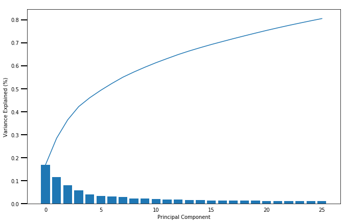

```python
#Insight for the scree_plot function was gotten from the udacity classroom
def scree_plot(pca):


    num_components = len(pca.explained_variance_ratio_)
    ind = np.arange(num_components)
    vals = pca.explained_variance_ratio_

    plt.figure(figsize=(11, 7))
    ax = plt.subplot(111)
    cumvals = np.cumsum(vals)
    ax.bar(ind, vals)

    ax.plot(ind, cumvals)



    ax.xaxis.set_tick_params(width=0)
    ax.yaxis.set_tick_params(width=2, length=12)

    ax.set_xlabel("Principal Component")
    ax.set_ylabel("Variance Explained (%)")

scree_plot(pca)
```

```python
# Re-apply PCA to the data while selecting for number of components to retain.
pca= PCA(n_components=30)
df_pca = pca.fit_transform(scaled_azdias)
```

```python
pca, X_pca = do_pca(30, scaled_azdias)
```

```python
pca
```

```
PCA(copy=True, iterated_power='auto', n_components=30, random_state=None,
  svd_solver='auto', tol=0.0, whiten=False)
```

```python
X_pca.shape
```

```
(797920, 30)
```

```python
pca.explained_variance_ratio_.sum()
```

```
0.84046650810506918
```

30 components explain 84% of variance in the dataset

Interpret Principal Components

Here, we will create a function to help calculate our pca dimensions

```python
#Insight for this function was drawn from Knowledge
def pca_dims(full_dataset, pca):
    '''
    Create a DataFrame of the PCA results
    Includes dimension feature weights and explained variance
    '''

    # Dimension indexing
    dimensions = ['Dimension {}'.format(i) for i in range(1,len(pca.components_)+1)]

    # PCA components
    components = pd.DataFrame(np.round(pca.components_, 4), columns = full_dataset.keys())
    components.index = dimensions

    # PCA explained variance
    ratios = pca.explained_variance_ratio_.reshape(len(pca.components_), 1)
    variance_ratios = pd.DataFrame(np.round(ratios, 4), columns = ['Explained Variance'])
    variance_ratios.index = dimensions


    # Return a concatenated DataFrame
    return pd.concat([variance_ratios, components], axis = 1)
```

```python
pca_dims(scaled_azdias, pca)
```

|  | Explained Variance | ANZ_HAUSHALTE_AKTIV | ANZ_HH_TITEL | ANZ_PERSONEN | ANZ_TITEL | ARBEIT | BALLRAUM | CJT_GESAMTTYP | EWDICHTE | FINANZ_ANLEGER | ... | SOHO_KZ | VERS_TYP | W_KEIT_KIND_HH | WOHNDAUER_2008 | WOHNLAGE | ZABEOTYP | ANREDE_KZ | ALTERSKATEGORIE_GROB | CAMEO_INTL_2015_LIFE_STAGE | CAMEO_INTL_2015_WEALTH |
| --- | --- | --- | --- | --- | --- | --- | --- | --- | --- | --- | --- | --- | --- | --- | --- | --- | --- | --- | --- | --- | --- |
| Dimension 1 | 0.1688 | 0.1259 | 0.0318 | -0.1045 | -0.0041 | 0.1267 | -0.1135 | 0.0312 | 0.1764 | 0.0420 | ... | -0.0024 | -0.0089 | 0.0540 | -0.0543 | -0.0767 | 0.1300 | 0.0162 | -0.0730 | -0.1079 | -0.1869 |
| Dimension 2 | 0.1152 | 0.0401 | 0.0246 | -0.0692 | 0.0066 | 0.0428 | -0.0368 | -0.1293 | 0.0567 | -0.2091 | ... | -0.0018 | 0.0244 | 0.1233 | 0.0623 | -0.0366 | -0.0304 | 0.0785 | 0.2539 | 0.0206 | -0.0413 |
| Dimension 3 | 0.0798 | 0.0239 | 0.0119 | -0.0166 | 0.0084 | 0.0359 | -0.0323 | -0.0379 | 0.0428 | -0.1783 | ... | 0.0002 | 0.0391 | 0.0934 | 0.0286 | -0.0175 | -0.0604 | -0.3662 | 0.0626 | -0.0112 | -0.0284 |
| Dimension 4 | 0.0579 | 0.0326 | 0.0230 | 0.3164 | 0.0234 | 0.1019 | -0.1386 | 0.0569 | 0.1746 | -0.0538 | ... | 0.0043 | 0.0494 | -0.1882 | 0.0821 | -0.1314 | -0.0749 | 0.0195 | 0.0016 | -0.0122 | -0.0187 |
| Dimension 5 | 0.0385 | 0.0678 | -0.0183 | 0.1486 | -0.0314 | -0.0287 | 0.2132 | -0.0283 | -0.2357 | 0.1341 | ... | 0.0011 | -0.0378 | -0.0820 | 0.0638 | 0.2749 | 0.0766 | -0.0219 | 0.0643 | -0.0725 | -0.1523 |
| Dimension 6 | 0.0325 | 0.0192 | 0.0217 | 0.0817 | 0.0222 | -0.1043 | -0.0272 | 0.0525 | 0.0286 | 0.0025 | ... | 0.0038 | -0.4385 | -0.0856 | 0.0593 | -0.0342 | -0.0624 | 0.0211 | 0.0932 | -0.0028 | 0.0123 |
| Dimension 7 | 0.0295 | -0.0832 | -0.0466 | -0.0470 | -0.0022 | 0.2005 | -0.0462 | 0.0503 | 0.0574 | 0.0397 | ... | 0.0018 | -0.2555 | -0.0041 | 0.0153 | -0.0440 | -0.0378 | 0.0387 | 0.0112 | 0.0267 | 0.0166 |
| Dimension 8 | 0.0274 | 0.3001 | 0.2183 | -0.0244 | 0.0647 | -0.1420 | -0.0111 | 0.0031 | -0.0823 | 0.0135 | ... | -0.0005 | -0.0831 | -0.0572 | -0.0349 | 0.1158 | -0.0610 | 0.0241 | 0.0068 | 0.0412 | 0.0924 |
| Dimension 9 | 0.0227 | 0.1582 | 0.0443 | -0.0348 | -0.0228 | -0.0546 | -0.1192 | 0.0567 | 0.0919 | 0.0134 | ... | 0.0031 | 0.0079 | 0.0372 | -0.0672 | -0.0452 | -0.0179 | -0.0220 | 0.0125 | -0.0525 | -0.0111 |
| Dimension 10 | 0.0209 | 0.2268 | 0.1942 | 0.0499 | 0.0709 | -0.0150 | -0.0956 | -0.0834 | 0.0645 | -0.0428 | ... | 0.0009 | 0.0934 | 0.1194 | 0.2003 | -0.0277 | 0.0344 | 0.0280 | -0.1205 | 0.1083 | 0.0493 |
| Dimension 11 | 0.0195 | -0.0187 | -0.0515 | -0.0205 | -0.0208 | 0.0974 | 0.0593 | -0.0504 | -0.0402 | -0.0952 | ... | -0.0044 | -0.0946 | -0.0072 | 0.1299 | 0.0707 | 0.0727 | 0.0625 | -0.1424 | -0.0552 | -0.0769 |
| Dimension 12 | 0.0179 | 0.0422 | -0.0052 | -0.0130 | -0.0209 | 0.4325 | 0.0544 | 0.0732 | -0.0201 | 0.1750 | ... | 0.0003 | -0.0262 | -0.0359 | -0.0154 | -0.0874 | 0.0053 | -0.0117 | 0.0419 | 0.1701 | 0.0220 |
| Dimension 13 | 0.0175 | -0.0215 | 0.0340 | -0.0200 | 0.0488 | -0.1312 | 0.1044 | 0.0219 | -0.0847 | 0.1238 | ... | -0.0048 | -0.0004 | 0.0331 | 0.0035 | 0.2555 | 0.0108 | 0.0105 | 0.0387 | -0.2444 | -0.1268 |
| Dimension 14 | 0.0156 | 0.1390 | 0.6079 | -0.0045 | 0.6130 | 0.1286 | 0.1609 | -0.0410 | -0.0499 | 0.0071 | ... | 0.0089 | -0.0012 | 0.0365 | -0.0464 | -0.0409 | -0.0068 | 0.0022 | 0.0037 | 0.0417 | -0.0546 |
| Dimension 15 | 0.0144 | 0.0663 | 0.1363 | -0.0093 | 0.1038 | -0.0538 | -0.1778 | 0.3808 | 0.0625 | -0.0320 | ... | -0.0251 | -0.0352 | -0.2677 | -0.2104 | 0.0007 | 0.2295 | -0.0676 | 0.0797 | -0.0907 | 0.0049 |
| Dimension 16 | 0.0137 | -0.1348 | 0.0529 | 0.0031 | 0.2226 | -0.2202 | -0.2578 | -0.0069 | 0.0283 | 0.0498 | ... | 0.0200 | 0.0162 | 0.1437 | -0.0211 | 0.0617 | -0.1005 | 0.0300 | -0.0656 | 0.3347 | 0.2036 |
| Dimension 17 | 0.0128 | 0.0088 | -0.0021 | -0.0004 | -0.0129 | -0.0058 | 0.0224 | 0.0443 | -0.0076 | -0.0082 | ... | 0.9907 | 0.0094 | 0.0036 | -0.0291 | -0.0062 | -0.0431 | 0.0043 | -0.0105 | -0.0083 | -0.0021 |
| Dimension 18 | 0.0127 | -0.0428 | 0.0105 | -0.0199 | 0.1197 | -0.0559 | -0.0459 | 0.0373 | 0.0261 | 0.1124 | ... | 0.0762 | -0.0103 | -0.2246 | 0.5785 | 0.0134 | 0.1439 | -0.0478 | 0.0432 | -0.0496 | 0.0050 |
| Dimension 19 | 0.0122 | -0.0474 | -0.0305 | 0.0033 | 0.1632 | -0.1127 | 0.1270 | 0.1696 | -0.0223 | 0.0157 | ... | -0.0933 | 0.0728 | -0.0316 | 0.1242 | -0.0119 | -0.1447 | 0.0230 | -0.1081 | -0.0772 | -0.0075 |
| Dimension 20 | 0.0119 | -0.1564 | -0.1235 | 0.0229 | 0.2938 | 0.0810 | -0.1324 | -0.4783 | 0.0449 | 0.0620 | ... | 0.0326 | 0.0061 | -0.0143 | 0.0870 | 0.0773 | 0.0025 | -0.0034 | 0.0194 | -0.2240 | -0.0194 |
| Dimension 21 | 0.0117 | 0.0735 | 0.1079 | 0.0116 | -0.1264 | 0.0057 | -0.1874 | -0.1467 | 0.0642 | 0.0353 | ... | 0.0260 | 0.0294 | -0.0931 | -0.0677 | 0.1129 | 0.1070 | -0.0198 | 0.0117 | -0.1360 | -0.0311 |
| Dimension 22 | 0.0110 | -0.0216 | 0.0197 | 0.0097 | -0.0170 | 0.0474 | 0.0560 | -0.1316 | -0.0104 | 0.0304 | ... | 0.0061 | 0.1335 | -0.0474 | -0.2825 | 0.0072 | -0.0923 | 0.0012 | -0.1421 | 0.1315 | 0.0550 |
| Dimension 23 | 0.0107 | -0.1980 | -0.2716 | 0.0082 | 0.4531 | 0.0543 | -0.0782 | 0.2720 | 0.0175 | -0.0705 | ... | 0.0031 | 0.0140 | 0.0867 | -0.0981 | 0.0658 | -0.0787 | 0.0235 | -0.0091 | -0.4435 | -0.1385 |
| Dimension 24 | 0.0102 | 0.0315 | -0.0016 | -0.0014 | 0.0884 | -0.1241 | -0.0520 | -0.2311 | 0.0446 | -0.0120 | ... | 0.0133 | -0.0901 | -0.1518 | -0.3672 | 0.0434 | 0.1879 | -0.0247 | 0.0964 | 0.0425 | -0.0117 |
| Dimension 25 | 0.0100 | -0.2091 | -0.3190 | 0.0075 | 0.3271 | 0.0137 | 0.1056 | 0.1298 | -0.0083 | -0.0261 | ... | 0.0095 | -0.0013 | -0.1139 | 0.0539 | 0.0177 | 0.2870 | -0.0466 | 0.0492 | 0.4821 | 0.2199 |
| Dimension 26 | 0.0096 | -0.0502 | -0.0004 | -0.0332 | 0.0070 | -0.0026 | 0.0832 | -0.2822 | -0.0092 | -0.0696 | ... | 0.0122 | -0.0771 | -0.0070 | -0.3202 | -0.0487 | 0.2975 | -0.0063 | 0.0181 | -0.0167 | 0.0096 |
| Dimension 27 | 0.0095 | 0.0326 | 0.2240 | -0.0065 | -0.1791 | 0.0732 | -0.0494 | 0.2116 | 0.0127 | 0.0002 | ... | -0.0072 | -0.1153 | -0.1001 | 0.0943 | 0.2898 | -0.0931 | 0.0295 | 0.0846 | 0.0895 | 0.0714 |
| Dimension 28 | 0.0091 | 0.0198 | -0.0444 | -0.0398 | 0.0255 | -0.0833 | 0.0082 | -0.0405 | -0.0344 | -0.0273 | ... | 0.0081 | -0.0140 | 0.0241 | 0.0926 | -0.3071 | 0.2947 | -0.0075 | 0.1104 | -0.0218 | 0.0125 |
| Dimension 29 | 0.0088 | -0.0210 | 0.1114 | -0.0353 | -0.0794 | 0.0795 | -0.1818 | 0.0871 | -0.0019 | -0.1472 | ... | 0.0134 | 0.0904 | 0.2329 | 0.1598 | 0.3477 | 0.5136 | -0.0088 | -0.0719 | 0.0153 | 0.0436 |
| Dimension 30 | 0.0083 | -0.0660 | 0.2026 | 0.0149 | -0.1192 | -0.0811 | 0.2263 | 0.1059 | 0.0103 | -0.0394 | ... | 0.0042 | 0.0171 | 0.0219 | 0.1141 | -0.4445 | 0.1832 | -0.0454 | -0.0297 | -0.1733 | -0.0011 |

30 rows × 79 columns

```python
#Insight for this function was drawn from Knowledge
def pca_results(full_dataset, pca):

    dimensions = ['Dimension {}'.format(i) for i in range(1,len(pca.components_)+1)]
    #PCA components
    components = pd.DataFrame(np.round(pca.components_, 4), columns = full_dataset.keys())
    components.index = dimensions

    # PCA explained variance
    ratios = pca.explained_variance_ratio_.reshape(len(pca.components_), 1)
    variance_ratios = pd.DataFrame(np.round(ratios, 4), columns = ['Explained Variance'])
    variance_ratios.index = dimensions

    # Create a bar plot visualization
    fig, ax = plt.subplots(figsize = (15,10))

    # Plot the feature weights as a function of the components
    components.plot(ax = ax, kind = 'bar');
    ax.set_ylabel("Feature Weights")
    ax.set_xticklabels(dimensions, rotation=0)

    # Display the explained variance ratios
    for i, ev in enumerate(pca.explained_variance_ratio_):
        ax.text(i-0.40, ax.get_ylim()[1] + 0.03, "Explained Variance\n          %.4f"%(ev))

    # Return a concatenated DataFrame
    #return pd.concat([variance_ratios, components], axis = 1)
```

[figure not shown]

```python
pca_results(scaled_azdias, pca)
```

```python
data=pd.DataFrame(pca.components_, columns = scaled_azdias.columns)
weights= data.sort_values
display(weights)
```

[output not shown]

[output cut: 146 more lines]

```python
# Map weights for the first principal component to corresponding feature names and then print the linked values, sorted by weight.
def pca_weights(item, pca):
    df = pd.DataFrame(pca.components_, columns=scaled_azdias.columns)
    weights = df.iloc[item].sort_values(ascending=False)
    return weights
```

```python
pca_weights(0,pca)
```

```
PLZ8_ANTG3                    0.203879
PLZ8_ANTG4                    0.197068
PLZ8_BAUMAX                   0.193359
HH_EINKOMMEN_SCORE            0.192828
ORTSGR_KLS9                   0.178518
EWDICHTE                      0.176368
FINANZ_HAUSBAUER              0.163424
KBA05_ANTG4                   0.141163
PLZ8_ANTG2                    0.139875
ZABEOTYP                      0.130003
KBA05_ANTG3                   0.127434
ARBEIT                        0.126743
ANZ_HAUSHALTE_AKTIV           0.125866
RELAT_AB                      0.120396
FINANZ_SPARER                 0.108376
SEMIO_PFLICHT                 0.079140
SEMIO_REL                     0.074859
GEBAEUDETYP                   0.069971
REGIOTYP                      0.068475
SEMIO_RAT                     0.066275
GFK_URLAUBERTYP               0.058806
SEMIO_TRADV                   0.055141
SEMIO_MAT                     0.054530
W_KEIT_KIND_HH                0.053954
SEMIO_FAM                     0.050903
KKK                           0.048856
OST_WEST_KZ                   0.046891
FINANZ_UNAUFFAELLIGER         0.046700
SEMIO_KAEM                    0.043809
FINANZ_ANLEGER                0.041968
PRAEGENDE_JUGENDJAHRE         0.041207
SEMIO_KULT                    0.040687
PLZ8_HHZ                      0.040291
ANZ_HH_TITEL                  0.031783
CJT_GESAMTTYP                 0.031162
SEMIO_DOM                     0.027019
NATIONALITAET_KZ              0.027013
SEMIO_SOZ                     0.025999
SEMIO_KRIT                    0.019577
KBA05_ANTG2                   0.016949
```

[output cut: 24 more lines]

```
BALLRAUM                     -0.113515
LP_LEBENSPHASE_GROB          -0.143382
INNENSTADT                   -0.147391
PLZ8_GBZ                     -0.149317
KONSUMNAEHE                  -0.153097
LP_LEBENSPHASE_FEIN          -0.156232
CAMEO_INTL_2015_WEALTH       -0.186866
KBA05_ANTG1                  -0.195624
FINANZ_MINIMALIST            -0.197406
KBA05_GBZ                    -0.198371
PLZ8_ANTG1                   -0.203671
MOBI_REGIO                   -0.205014
LP_STATUS_GROB               -0.216289
LP_STATUS_FEIN               -0.219260
Name: 0, dtype: float64
```

```python
pca_weights(1,pca)
```

```
ALTERSKATEGORIE_GROB          0.253892
FINANZ_VORSORGER              0.240717
SEMIO_ERL                     0.229616
SEMIO_LUST                    0.186001
RETOURTYP_BK_S                0.164378
W_KEIT_KIND_HH                0.123325
FINANZTYP                     0.115291
SEMIO_KRIT                    0.108714
FINANZ_MINIMALIST             0.098292
SEMIO_KAEM                    0.095553
SHOPPER_TYP                   0.093295
FINANZ_HAUSBAUER              0.087507
ANREDE_KZ                     0.078530
WOHNDAUER_2008                0.062275
SEMIO_DOM                     0.059966
EWDICHTE                      0.056737
ORTSGR_KLS9                   0.055469
PLZ8_ANTG3                    0.053538
PLZ8_ANTG4                    0.053120
PLZ8_BAUMAX                   0.049155
KBA05_ANTG4                   0.045325
ARBEIT                        0.042756
RELAT_AB                      0.040630
ANZ_HAUSHALTE_AKTIV           0.040120
PLZ8_ANTG2                    0.037221
HH_EINKOMMEN_SCORE            0.027414
ANZ_HH_TITEL                  0.024563
VERS_TYP                      0.024447
KBA05_ANTG3                   0.023780
CAMEO_INTL_2015_LIFE_STAGE    0.020606
OST_WEST_KZ                   0.018618
REGIOTYP                      0.014234
PLZ8_HHZ                      0.007286
KKK                           0.006738
ANZ_TITEL                     0.006556
GEBAEUDETYP                   0.006505
LP_STATUS_GROB                0.003169
SOHO_KZ                      -0.001752
KBA05_ANTG2                  -0.003204
GREEN_AVANTGARDE             -0.004389
```

[output cut: 24 more lines]

```
SEMIO_SOZ                    -0.100765
CJT_GESAMTTYP                -0.129254
SEMIO_MAT                    -0.165346
ONLINE_AFFINITAET            -0.165570
SEMIO_RAT                    -0.180156
SEMIO_FAM                    -0.182734
FINANZ_ANLEGER               -0.209074
SEMIO_KULT                   -0.216314
FINANZ_UNAUFFAELLIGER        -0.232112
SEMIO_PFLICHT                -0.235966
SEMIO_TRADV                  -0.236582
PRAEGENDE_JUGENDJAHRE        -0.248000
FINANZ_SPARER                -0.249653
SEMIO_REL                    -0.258465
Name: 1, dtype: float64
```

```python
pca_weights(2,pca)
```

```
SEMIO_VERT                    0.339363
SEMIO_SOZ                     0.260331
SEMIO_FAM                     0.252531
SEMIO_KULT                    0.240226
FINANZ_MINIMALIST             0.154224
FINANZTYP                     0.119284
RETOURTYP_BK_S                0.103516
W_KEIT_KIND_HH                0.093420
FINANZ_VORSORGER              0.090234
SEMIO_REL                     0.078035
ALTERSKATEGORIE_GROB          0.062569
SEMIO_MAT                     0.059802
SEMIO_LUST                    0.053216
PLZ8_BAUMAX                   0.049787
PLZ8_ANTG4                    0.046290
ORTSGR_KLS9                   0.044564
PLZ8_ANTG3                    0.043979
EWDICHTE                      0.042796
VERS_TYP                      0.039106
GREEN_AVANTGARDE              0.038384
LP_STATUS_GROB                0.037317
ARBEIT                        0.035928
RELAT_AB                      0.030327
WOHNDAUER_2008                0.028579
PLZ8_ANTG2                    0.027821
KBA05_ANTG4                   0.027187
ANZ_HAUSHALTE_AKTIV           0.023897
LP_STATUS_FEIN                0.022747
OST_WEST_KZ                   0.021271
HEALTH_TYP                    0.016088
ANZ_HH_TITEL                  0.011943
GEBAEUDETYP                   0.008965
ANZ_TITEL                     0.008360
KBA05_ANTG3                   0.008187
PLZ8_HHZ                      0.002149
REGIOTYP                      0.001580
SOHO_KZ                       0.000223
NATIONALITAET_KZ             -0.001522
KKK                          -0.004286
LP_LEBENSPHASE_FEIN          -0.005352
```

[output cut: 24 more lines]

```
ZABEOTYP                     -0.060394
SEMIO_PFLICHT                -0.068310
SEMIO_TRADV                  -0.069909
PRAEGENDE_JUGENDJAHRE        -0.076949
SHOPPER_TYP                  -0.091339
FINANZ_UNAUFFAELLIGER        -0.096925
FINANZ_SPARER                -0.097722
FINANZ_ANLEGER               -0.178272
SEMIO_ERL                    -0.182230
SEMIO_RAT                    -0.206980
SEMIO_KRIT                   -0.272290
SEMIO_DOM                    -0.309506
SEMIO_KAEM                   -0.334549
ANREDE_KZ                    -0.366197
Name: 2, dtype: float64
```

Summary:

### For the first component:

The first principal component has a strong correlation with PLZ8_ANTG3 and PLZ8_ANTG4, which are the number of 6-10 family houses in the PLZ8 region and number of 10+ family houses in the PLZ8 region repectively. This implies that the two features varies together. An increase in the number of number of 6-10 family houses will result in a corrsponding increase in the number of 10+ family houses in the PLZ8 region. Therfore have an increase in the number of 6-10 family houses and 10+ family houses in the PLZ8 region is what we want.

Also the first component has a strong negative correlation with LP_STATUS_GROB and LP_STATUS_FEIN, which are the Movement patterns and Low financial interest typology respectively. This implies that the two features varies together. An increase in the Movement patterns will result in a corrsponding increase in the Low financial interest typology. Therfore have an decrease in the Movement patterns and Low financial interest typology is what we want.

### For the second component:

The second principal component has a strong correlation with ALTERSKATEGORIE_GROB and FINANZ_VORSORGER, which are the Estimated age based on given name analysis and Financial typology(VORSORGER) repectively. This implies that the two features varies together. An increase in the Estimated age will result in a corrsponding increase in the Financial typology(VORSORGER). Therfore have an increase in the Estimated age and Financial typology(VORSORGER) is what we want.

### For the third component:

The third principal component has a strong correlation with SEMIO_VERT and SEMIO_SOZ, which are the Personality typology(VERT: dreamful) and Personality typology(socially-minded) repectively. This implies that the two features varies together. An increase in the Personality typology(VERT: dreamful) will result in a corrsponding increase in the Personality typology(socially-minded)). Therfore have an increase in the Personality typology(VERT: dreamful) and Personality typology(socially-minded) is what we want.

Also the third component has a strong negative correlation with ANREDE_KZ and SEMIO_KAEM, which are the Gender and the Personal typology(combative attitude) respectively. This implies that the two features varies together. An increase in the Gender will result in a corrsponding increase in the Personal typology(combative attitude). Therfore have an decrease in the Gender and Personal typology(combative attitude)is what we want.

Apply Clustering to General Population

```python
# Over a number of different cluster counts...
from sklearn.cluster import KMeans

def kmeans_score(data, clusters):

    kmeans=KMeans(n_clusters=clusters)
    model = kmeans.fit(data)
    score = np.abs(model.score(data))

    return score

    # run k-means clustering on the data and...
```

```python
score = []

clusters = list(range(2,8))

for cluster in clusters:
    score.append(kmeans_score(X_pca, cluster))
```

```python
score
```

```
[44400336.587115481,
 40918105.112919196,
 38741580.386490263,
 37294780.064058572,
 35946239.923405163,
 34739821.567578845]
```

### Refinement

```
Text(0.5,1,'Elbow Curve')
```

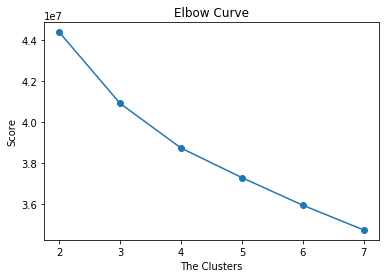

```python
# Investigating the change in within-cluster distance across number of clusters.
# Using matplotlib's plot function to visualize this relationship.
plt.plot(clusters, score, linestyle='-', marker='o')
plt.xlabel('The Clusters')
plt.ylabel('Score')
plt.title("Elbow Curve")
```

```python
# Re-fiting the k-means model with the selected number of clusters and obtain
# cluster predictions for the general population demographics data.
kmeans= KMeans(4)
```

```python
model = kmeans.fit(X_pca)
```

```python
model
```

```
KMeans(algorithm='auto', copy_x=True, init='k-means++', max_iter=300,
    n_clusters=4, n_init=10, n_jobs=1, precompute_distances='auto',
    random_state=None, tol=0.0001, verbose=0)
```

```python
scaled_azdias_pred = model.predict(X_pca)
scaled_azdias_pred
```

```
array([3, 2, 1, ..., 2, 3, 0], dtype=int32)
```

Apply All Steps to the Customer Data

```python
customers_new.head()
```

|  | ANZ_HAUSHALTE_AKTIV | ANZ_HH_TITEL | ANZ_PERSONEN | ANZ_TITEL | ARBEIT | BALLRAUM | CJT_GESAMTTYP | EWDICHTE | FINANZ_ANLEGER | FINANZ_HAUSBAUER | ... | SOHO_KZ | VERS_TYP | W_KEIT_KIND_HH | WOHNDAUER_2008 | WOHNLAGE | ZABEOTYP | ANREDE_KZ | ALTERSKATEGORIE_GROB | CAMEO_INTL_2015_LIFE_STAGE | CAMEO_INTL_2015_WEALTH |
| --- | --- | --- | --- | --- | --- | --- | --- | --- | --- | --- | --- | --- | --- | --- | --- | --- | --- | --- | --- | --- | --- |
| 0 | 1 | 0 | 2 | 0 | 1 | 3 | 5 | 2 | 1 | 2 | ... | 0 | 1 | 6 | 9 | 7 | 3 | 1 | 4 | 3 | 5 |
| 2 | 1 | 0 | 1 | 0 | 3 | 7 | 2 | 4 | 1 | 4 | ... | 0 | 2 | 6 | 9 | 2 | 3 | 2 | 4 | 4 | 3 |
| 4 | 7 | 0 | 4 | 0 | 3 | 3 | 6 | 4 | 4 | 2 | ... | 0 | 2 | 2 | 9 | 3 | 1 | 1 | 3 | 1 | 2 |
| 5 | 1 | 0 | 2 | 0 | 3 | 7 | 4 | 5 | 1 | 3 | ... | 0 | 2 | 6 | 9 | 1 | 2 | 1 | 3 | 4 | 3 |
| 6 | 1 | 0 | 2 | 0 | 2 | 6 | 2 | 2 | 1 | 2 | ... | 0 | 1 | 6 | 9 | 7 | 1 | 1 | 4 | 3 | 4 |

5 rows × 78 columns

Let's start by scalling the datast

```python
scaled_customers= scaler.transform(customers_new)
scaled_customers=pd.DataFrame(scaled_customers, columns=customers_new.columns )
```

```python
scaled_customers.head()
```

|  | ANZ_HAUSHALTE_AKTIV | ANZ_HH_TITEL | ANZ_PERSONEN | ANZ_TITEL | ARBEIT | BALLRAUM | CJT_GESAMTTYP | EWDICHTE | FINANZ_ANLEGER | FINANZ_HAUSBAUER | ... | SOHO_KZ | VERS_TYP | W_KEIT_KIND_HH | WOHNDAUER_2008 | WOHNLAGE | ZABEOTYP | ANREDE_KZ | ALTERSKATEGORIE_GROB | CAMEO_INTL_2015_LIFE_STAGE | CAMEO_INTL_2015_WEALTH |
| --- | --- | --- | --- | --- | --- | --- | --- | --- | --- | --- | --- | --- | --- | --- | --- | --- | --- | --- | --- | --- | --- |
| 0 | -0.466328 | -0.125135 | 0.234395 | -0.060382 | -2.168782 | -0.528662 | 0.974314 | -1.128873 | -1.250003 | -0.791484 | ... | -0.092125 | -0.559347 | 0.995627 | 0.567198 | 1.511841 | -0.269017 | -1.043967 | 1.094305 | 0.095022 | 1.551473 |
| 1 | -0.466328 | -0.125135 | -0.630256 | -0.060382 | -0.171888 | 1.303252 | -0.981871 | 0.034420 | -1.250003 | 0.628967 | ... | -0.092125 | 0.832076 | 0.995627 | 0.567198 | -1.053230 | -0.269017 | 0.957884 | 1.094305 | 0.767017 | 0.187900 |
| 2 | -0.082430 | -0.125135 | 1.963695 | -0.060382 | -0.171888 | -0.528662 | 1.626375 | 0.034420 | 0.786910 | -0.791484 | ... | -0.092125 | 0.832076 | -1.103537 | 0.567198 | -0.540216 | -1.689713 | -1.043967 | 0.169126 | -1.248969 | -0.493887 |
| 3 | -0.466328 | -0.125135 | 0.234395 | -0.060382 | -0.171888 | 1.303252 | 0.322252 | 0.616067 | -1.250003 | -0.081259 | ... | -0.092125 | 0.832076 | 0.995627 | 0.567198 | -1.566244 | -0.979365 | -1.043967 | 0.169126 | 0.767017 | 0.187900 |
| 4 | -0.466328 | -0.125135 | 0.234395 | -0.060382 | -1.170335 | 0.845273 | -0.981871 | -1.128873 | -1.250003 | -0.791484 | ... | -0.092125 | -0.559347 | 0.995627 | 0.567198 | 1.511841 | -1.689713 | -1.043967 | 1.094305 | 0.095022 | 0.869686 |

5 rows × 78 columns

We will project the clustering from the general demographics onto the customer data, obtaining cluster predictions for the customer demographics data.

```python
customers_pca = pca.transform(scaled_customers)
pred_customers = model.predict(customers_pca)
```

```python
pred_customers
```

```
array([1, 0, 2, ..., 1, 1, 1], dtype=int32)
```

Now we will compare the proportion of data in each cluster for the customer data to the proportion of data in each cluster for the generalpopulation.

```python
#Insight drawn from Knwoledge
def compare(x,y):
    sns.set_style("whitegrid")
    fig, (bx1, bx2) = plt.subplots(1, 2, figsize = (15,5), )

    bx1.set_title('General', fontweight = 'bold')
    sns.countplot(x,ax = bx1, color='r')

    bx2.set_title('Customers', fontweight = 'bold')
    sns.countplot(y, ax = bx2, color='g')
    plt.show()
```

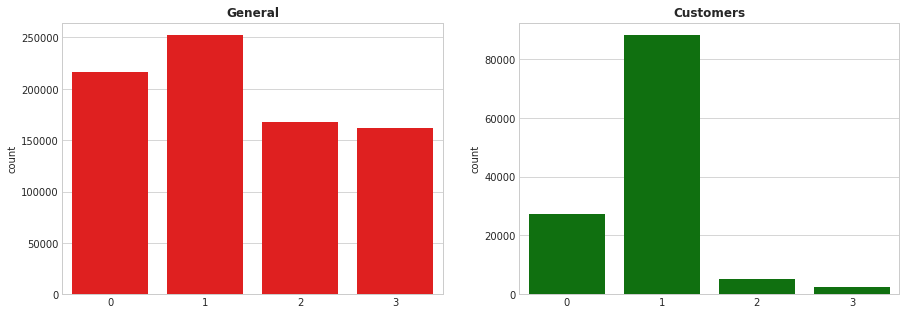

```python
compare(scaled_azdias_pred, pred_customers)
```

```python
pred_cust = pd.Series(pred_customers).value_counts().sort_index()
data_prediction = pd.Series(scaled_azdias_pred).value_counts().sort_index()
df_new = pd.concat([data_prediction, pred_cust], axis=1).reset_index()
df_new.columns = ['Cluster','General_Prediction', 'Customer_Prediction']
df_new
```

|  | Cluster | General_Prediction | Customer_Prediction |
| --- | --- | --- | --- |
| 0 | 0 | 216171 | 27280 |
| 1 | 1 | 251975 | 88034 |
| 2 | 2 | 167497 | 5330 |
| 3 | 3 | 162277 | 2561 |

Now, let us obtain our centriods

```python
centroid_1= scaler.inverse_transform(pca.inverse_transform(model.cluster_centers_[1]))
```

```python
data1 = pd.Series(data = centroid_1, index = customers_new.columns)
data1
```

```
ANZ_HAUSHALTE_AKTIV              1.749123
ANZ_HH_TITEL                     0.011124
ANZ_PERSONEN                     2.039189
ANZ_TITEL                        0.005558
ARBEIT                           2.787813
BALLRAUM                         4.835989
CJT_GESAMTTYP                    3.063492
EWDICHTE                         3.018088
FINANZ_ANLEGER                   2.152807
FINANZ_HAUSBAUER                 2.269847
FINANZ_MINIMALIST                4.398044
FINANZ_SPARER                    1.621641
FINANZ_UNAUFFAELLIGER            1.988442
FINANZ_VORSORGER                 4.242936
FINANZTYP                        4.584366
GEBAEUDETYP                      2.114214
GEBAEUDETYP_RASTER               4.049738
GFK_URLAUBERTYP                  6.587519
GREEN_AVANTGARDE                 0.418084
HEALTH_TYP                       2.070966
HH_EINKOMMEN_SCORE               3.230133
INNENSTADT                       5.421247
KBA05_ANTG1                      2.506688
KBA05_ANTG2                      1.005649
KBA05_ANTG3                      0.075833
KBA05_ANTG4                      0.009563
KBA05_GBZ                        4.100701
KBA13_ANZAHL_PKW               686.793156
KKK                              2.445109
KONSUMNAEHE                      3.790427
LP_FAMILIE_FEIN                  4.789198
LP_FAMILIE_GROB                  2.746191
LP_LEBENSPHASE_FEIN             21.940763
LP_LEBENSPHASE_GROB              6.438181
LP_STATUS_FEIN                   8.068654
LP_STATUS_GROB                   3.895757
MIN_GEBAEUDEJAHR              1993.613441
MOBI_REGIO                       4.004787
NATIONALITAET_KZ                 1.037600
ONLINE_AFFINITAET                2.875881
```

[output cut: 24 more lines]

```
SEMIO_SOZ                        3.820306
SEMIO_TRADV                      2.847252
SEMIO_VERT                       4.576018
SHOPPER_TYP                      1.573812
SOHO_KZ                          0.008882
VERS_TYP                         1.477870
W_KEIT_KIND_HH                   4.118773
WOHNDAUER_2008                   8.402183
WOHNLAGE                         4.555406
ZABEOTYP                         2.652947
ANREDE_KZ                        1.500934
ALTERSKATEGORIE_GROB             3.431532
CAMEO_INTL_2015_LIFE_STAGE       3.418810
CAMEO_INTL_2015_WEALTH           3.681758
dtype: float64
```

```python
centroid_0= scaler.inverse_transform(pca.inverse_transform(model.cluster_centers_[0]))
```

```python
data = pd.Series(data = centroid_0, index = customers_new.columns)
data
```

```
ANZ_HAUSHALTE_AKTIV             14.678807
ANZ_HH_TITEL                     0.083628
ANZ_PERSONEN                     1.354573
ANZ_TITEL                        0.004990
ARBEIT                           3.569248
BALLRAUM                         3.507873
CJT_GESAMTTYP                    3.103247
EWDICHTE                         4.861035
FINANZ_ANLEGER                   1.954712
FINANZ_HAUSBAUER                 4.007844
FINANZ_MINIMALIST                2.878701
FINANZ_SPARER                    1.895390
FINANZ_UNAUFFAELLIGER            1.682168
FINANZ_VORSORGER                 4.279864
FINANZTYP                        4.597562
GEBAEUDETYP                      3.329472
GEBAEUDETYP_RASTER               3.463775
GFK_URLAUBERTYP                  7.503871
GREEN_AVANTGARDE                 0.070128
HEALTH_TYP                       2.122717
HH_EINKOMMEN_SCORE               5.377648
INNENSTADT                       3.722368
KBA05_ANTG1                      0.459345
KBA05_ANTG2                      1.397744
KBA05_ANTG3                      1.086128
KBA05_ANTG4                      0.563958
KBA05_GBZ                        2.246725
KBA13_ANZAHL_PKW               573.628068
KKK                              2.751958
KONSUMNAEHE                      2.300195
LP_FAMILIE_FEIN                  2.384546
LP_FAMILIE_GROB                  1.672440
LP_LEBENSPHASE_FEIN             10.735998
LP_LEBENSPHASE_GROB              3.328786
LP_STATUS_FEIN                   2.359726
LP_STATUS_GROB                   1.522157
MIN_GEBAEUDEJAHR              1992.565230
MOBI_REGIO                       1.866821
NATIONALITAET_KZ                 1.090965
ONLINE_AFFINITAET                1.735116
```

[output cut: 24 more lines]

```
SEMIO_SOZ                        3.997831
SEMIO_TRADV                      2.636829
SEMIO_VERT                       4.162702
SHOPPER_TYP                      1.804933
SOHO_KZ                          0.007602
VERS_TYP                         1.569944
W_KEIT_KIND_HH                   4.883544
WOHNDAUER_2008                   8.094818
WOHNLAGE                         3.452809
ZABEOTYP                         3.595519
ANREDE_KZ                        1.543596
ALTERSKATEGORIE_GROB             3.465200
CAMEO_INTL_2015_LIFE_STAGE       2.572853
CAMEO_INTL_2015_WEALTH           1.825791
dtype: float64
```

```python
centroid_2= scaler.inverse_transform(pca.inverse_transform(model.cluster_centers_[2]))
data2 = pd.Series(data = centroid_2, index = customers_new.columns)
data2
```

```
ANZ_HAUSHALTE_AKTIV              3.191567
ANZ_HH_TITEL                     0.008820
ANZ_PERSONEN                     2.067805
ANZ_TITEL                        0.003078
ARBEIT                           2.772529
BALLRAUM                         4.947928
CJT_GESAMTTYP                    4.158488
EWDICHTE                         2.997281
FINANZ_ANLEGER                   4.048722
FINANZ_HAUSBAUER                 2.449799
FINANZ_MINIMALIST                2.769895
FINANZ_SPARER                    3.893733
FINANZ_UNAUFFAELLIGER            3.848006
FINANZ_VORSORGER                 2.314994
FINANZTYP                        2.857730
GEBAEUDETYP                      2.460880
GEBAEUDETYP_RASTER               3.985701
GFK_URLAUBERTYP                  7.632604
GREEN_AVANTGARDE                 0.242750
HEALTH_TYP                       2.099728
HH_EINKOMMEN_SCORE               3.859077
INNENSTADT                       5.449330
KBA05_ANTG1                      2.007514
KBA05_ANTG2                      1.222620
KBA05_ANTG3                      0.226243
KBA05_ANTG4                      0.047770
KBA05_GBZ                        3.820278
KBA13_ANZAHL_PKW               718.684760
KKK                              2.461999
KONSUMNAEHE                      3.692571
LP_FAMILIE_FEIN                  5.005168
LP_FAMILIE_GROB                  2.847583
LP_LEBENSPHASE_FEIN             18.067011
LP_LEBENSPHASE_GROB              5.562914
LP_STATUS_FEIN                   5.777304
LP_STATUS_GROB                   2.752579
MIN_GEBAEUDEJAHR              1994.367801
MOBI_REGIO                       3.521925
NATIONALITAET_KZ                 1.189843
ONLINE_AFFINITAET                3.708478
```

[output cut: 24 more lines]

```
SEMIO_SOZ                        4.358301
SEMIO_TRADV                      5.122644
SEMIO_VERT                       4.369959
SHOPPER_TYP                      1.225748
SOHO_KZ                          0.009340
VERS_TYP                         1.265427
W_KEIT_KIND_HH                   3.095251
WOHNDAUER_2008                   7.587740
WOHNLAGE                         4.532217
ZABEOTYP                         3.295072
ANREDE_KZ                        1.496871
ALTERSKATEGORIE_GROB             1.958620
CAMEO_INTL_2015_LIFE_STAGE       3.170854
CAMEO_INTL_2015_WEALTH           3.466041
dtype: float64
```

```python
centroid_3= scaler.inverse_transform(pca.inverse_transform(model.cluster_centers_[3]))
data3 = pd.Series(data = centroid_3, index = customers_new.columns)
data3
```

```
ANZ_HAUSHALTE_AKTIV             15.186739
ANZ_HH_TITEL                     0.061122
ANZ_PERSONEN                     1.396200
ANZ_TITEL                        0.001993
ARBEIT                           3.652189
BALLRAUM                         3.138534
CJT_GESAMTTYP                    4.055309
EWDICHTE                         5.121028
FINANZ_ANLEGER                   3.844070
FINANZ_HAUSBAUER                 3.921283
FINANZ_MINIMALIST                1.517268
FINANZ_SPARER                    4.293438
FINANZ_UNAUFFAELLIGER            3.770594
FINANZ_VORSORGER                 2.200481
FINANZTYP                        2.481670
GEBAEUDETYP                      3.503678
GEBAEUDETYP_RASTER               3.364910
GFK_URLAUBERTYP                  8.763433
GREEN_AVANTGARDE                 0.086446
HEALTH_TYP                       1.878478
HH_EINKOMMEN_SCORE               5.539848
INNENSTADT                       3.370498
KBA05_ANTG1                      0.402940
KBA05_ANTG2                      1.225409
KBA05_ANTG3                      1.118443
KBA05_ANTG4                      0.613230
KBA05_GBZ                        2.188682
KBA13_ANZAHL_PKW               535.167878
KKK                              2.816062
KONSUMNAEHE                      2.103033
LP_FAMILIE_FEIN                  2.726311
LP_FAMILIE_GROB                  1.827302
LP_LEBENSPHASE_FEIN              8.177650
LP_LEBENSPHASE_GROB              2.768768
LP_STATUS_FEIN                   1.815952
LP_STATUS_GROB                   1.138031
MIN_GEBAEUDEJAHR              1992.562577
MOBI_REGIO                       1.747444
NATIONALITAET_KZ                 1.208967
ONLINE_AFFINITAET                2.870000
```

[output cut: 24 more lines]

```
SEMIO_SOZ                        4.600051
SEMIO_TRADV                      5.091622
SEMIO_VERT                       3.869796
SHOPPER_TYP                      1.065231
SOHO_KZ                          0.007822
VERS_TYP                         1.201431
W_KEIT_KIND_HH                   4.077554
WOHNDAUER_2008                   7.229197
WOHNLAGE                         3.578144
ZABEOTYP                         4.302941
ANREDE_KZ                        1.549410
ALTERSKATEGORIE_GROB             1.886118
CAMEO_INTL_2015_LIFE_STAGE       2.047389
CAMEO_INTL_2015_WEALTH           1.669895
dtype: float64
```

Summary:

The same thing goes for other centriods but with differnt values

## Part 2: Supervised Learning Model

Now that you've found which parts of the population are more likely to be customers of the mail-order company, it's time to build a prediction model. Each of the rows in the "MAILOUT" data files represents an individual that was targeted for a mailout campaign. Ideally, we should be able to use the demographic information from each individual to decide whether or not it will be worth it to include that person in the campaign.

The "MAILOUT" data has been split into two approximately equal parts, each with almost 43 000 data rows. In this part, you can verify your model with the "TRAIN" partition, which includes a column, "RESPONSE", that states whether or not a person became a customer of the company following the campaign. In the next part, you'll need to create predictions on the "TEST" partition, where the "RESPONSE" column has been withheld.

```python
df_train = pd.read_csv('../../data/Term2/capstone/arvato_data/Udacity_MAILOUT_052018_TRAIN.csv', sep=';')
```

```python
df_train.head()
```

|  | LNR | AGER_TYP | AKT_DAT_KL | ALTER_HH | ALTER_KIND1 | ALTER_KIND2 | ALTER_KIND3 | ALTER_KIND4 | ALTERSKATEGORIE_FEIN | ANZ_HAUSHALTE_AKTIV | ... | VK_DHT4A | VK_DISTANZ | VK_ZG11 | W_KEIT_KIND_HH | WOHNDAUER_2008 | WOHNLAGE | ZABEOTYP | RESPONSE | ANREDE_KZ | ALTERSKATEGORIE_GROB |
| --- | --- | --- | --- | --- | --- | --- | --- | --- | --- | --- | --- | --- | --- | --- | --- | --- | --- | --- | --- | --- | --- |
| 0 | 1763 | 2 | 1.0 | 8.0 | NaN | NaN | NaN | NaN | 8.0 | 15.0 | ... | 5.0 | 2.0 | 1.0 | 6.0 | 9.0 | 3.0 | 3 | 0 | 2 | 4 |
| 1 | 1771 | 1 | 4.0 | 13.0 | NaN | NaN | NaN | NaN | 13.0 | 1.0 | ... | 1.0 | 2.0 | 1.0 | 4.0 | 9.0 | 7.0 | 1 | 0 | 2 | 3 |
| 2 | 1776 | 1 | 1.0 | 9.0 | NaN | NaN | NaN | NaN | 7.0 | 0.0 | ... | 6.0 | 4.0 | 2.0 | NaN | 9.0 | 2.0 | 3 | 0 | 1 | 4 |
| 3 | 1460 | 2 | 1.0 | 6.0 | NaN | NaN | NaN | NaN | 6.0 | 4.0 | ... | 8.0 | 11.0 | 11.0 | 6.0 | 9.0 | 1.0 | 3 | 0 | 2 | 4 |
| 4 | 1783 | 2 | 1.0 | 9.0 | NaN | NaN | NaN | NaN | 9.0 | 53.0 | ... | 2.0 | 2.0 | 1.0 | 6.0 | 9.0 | 3.0 | 3 | 0 | 1 | 3 |

5 rows × 367 columns

```python
df_train.RESPONSE.value_counts()
```

```
0    42430
1      532
Name: RESPONSE, dtype: int64
```

```python
df_train.shape
```

```
(42962, 367)
```

```python
a = ['ALTERSKATEGORIE_GROB','ANREDE_KZ','CJT_GESAMTTYP','FINANZ_MINIMALIST','FINANZ_SPARER','FINANZ_VORSORGER','FINANZ_ANLEGER','FINANZ_UNAUFFAELLIGER','FINANZ_HAUSBAUER','FINANZTYP','GFK_URLAUBERTYP','GREEN_AVANTGARDE',
 'HEALTH_TYP', 'LP_LEBENSPHASE_FEIN', 'LP_LEBENSPHASE_GROB','LP_FAMILIE_FEIN','LP_FAMILIE_GROB', 'LP_STATUS_FEIN', 'LP_STATUS_GROB', 'NATIONALITAET_KZ', 'PRAEGENDE_JUGENDJAHRE', 'RETOURTYP_BK_S', 'SEMIO_SOZ',
 'SEMIO_FAM','SEMIO_REL','SEMIO_MAT','SEMIO_VERT','SEMIO_LUST','SEMIO_ERL','SEMIO_KULT','SEMIO_RAT','SEMIO_KRIT','SEMIO_DOM', 'SEMIO_KAEM', 'SEMIO_PFLICHT','SEMIO_TRADV','SHOPPER_TYP','SOHO_KZ',
 'VERS_TYP','ZABEOTYP','ANZ_PERSONEN','ANZ_TITEL','HH_EINKOMMEN_SCORE','KK_KUNDENTYP','W_KEIT_KIND_HH','WOHNDAUER_2008','ANZ_HAUSHALTE_AKTIV','ANZ_HH_TITEL','GEBAEUDETYP','KONSUMNAEHE','MIN_GEBAEUDEJAHR','OST_WEST_KZ','WOHNLAGE','CAMEO_DEUG_2015','CAMEO_DEU_2015','CAMEO_INTL_2015','KBA05_ANTG1',
 'KBA05_ANTG2','KBA05_ANTG3','KBA05_ANTG4','KBA05_GBZ','BALLRAUM','EWDICHTE','INNENSTADT','GEBAEUDETYP_RASTER','KKK','MOBI_REGIO','ONLINE_AFFINITAET','REGIOTYP','KBA13_ANZAHL_PKW','PLZ8_ANTG1','PLZ8_ANTG2','PLZ8_ANTG3','PLZ8_ANTG4','PLZ8_BAUMAX','PLZ8_HHZ','PLZ8_GBZ','ARBEIT','ORTSGR_KLS9','RELAT_AB']
```

```python
df_train1=df_train[df_train.columns[df_train.columns.isin(a)]]
```

```python
df_train1.shape
```

```
(42962, 80)
```

```python
df_train1=clean_data(df_train1)
```

```python
df_train1.columns.difference(azdias6.columns)
```

```
Index(['KK_KUNDENTYP'], dtype='object')
```

```python
azdias6.columns.difference(df_train1.columns)
```

```
Index([], dtype='object')
```

```python
df_train1.drop(['KK_KUNDENTYP'], axis = 1)
```

|  | ANZ_HAUSHALTE_AKTIV | ANZ_HH_TITEL | ANZ_PERSONEN | ANZ_TITEL | ARBEIT | BALLRAUM | CJT_GESAMTTYP | EWDICHTE | FINANZ_ANLEGER | FINANZ_HAUSBAUER | ... | SOHO_KZ | VERS_TYP | W_KEIT_KIND_HH | WOHNDAUER_2008 | WOHNLAGE | ZABEOTYP | ANREDE_KZ | ALTERSKATEGORIE_GROB | CAMEO_INTL_2015_LIFE_STAGE | CAMEO_INTL_2015_WEALTH |
| --- | --- | --- | --- | --- | --- | --- | --- | --- | --- | --- | --- | --- | --- | --- | --- | --- | --- | --- | --- | --- | --- |
| 0 | 15.0 | 0.0 | 1.0 | 0.0 | 3.0 | 5.0 | 2.0 | 5.0 | 2 | 5 | ... | 0.0 | 2 | 6.0 | 9.0 | 3.0 | 3 | 2 | 4 | 4.0 | 3.0 |
| 1 | 1.0 | 0.0 | 2.0 | 0.0 | 2.0 | 5.0 | 2.0 | 1.0 | 2 | 3 | ... | 0.0 | 1 | 4.0 | 9.0 | 7.0 | 1 | 2 | 3 | 2.0 | 3.0 |
| 2 | 0.0 | NaN | 0.0 | 0.0 | 4.0 | 1.0 | 4.0 | 6.0 | 1 | 2 | ... | 0.0 | 1 | NaN | 9.0 | 2.0 | 3 | 1 | 4 | 4.0 | 5.0 |
| 3 | 4.0 | 0.0 | 2.0 | 0.0 | 4.0 | 2.0 | 2.0 | 6.0 | 1 | 5 | ... | 0.0 | 2 | 6.0 | 9.0 | 1.0 | 3 | 2 | 4 | 4.0 | 5.0 |
| 4 | 53.0 | 0.0 | 1.0 | 0.0 | 3.0 | 4.0 | 6.0 | 5.0 | 1 | 5 | ... | 0.0 | 1 | 6.0 | 9.0 | 3.0 | 3 | 1 | 3 | 1.0 | 2.0 |
| 5 | 17.0 | 0.0 | 1.0 | 0.0 | 4.0 | 1.0 | 4.0 | 6.0 | 1 | 5 | ... | 0.0 | 1 | 6.0 | 9.0 | 2.0 | 3 | 2 | 3 | 1.0 | 2.0 |
| 6 | 2.0 | 0.0 | 1.0 | 0.0 | 3.0 | 6.0 | 2.0 | 2.0 | 2 | 3 | ... | 0.0 | 2 | 6.0 | 9.0 | 2.0 | 3 | 2 | 4 | 4.0 | 4.0 |
| 7 | 1.0 | 0.0 | 2.0 | 0.0 | 1.0 | 7.0 | 2.0 | 1.0 | 2 | 3 | ... | 0.0 | 1 | 6.0 | 9.0 | 7.0 | 3 | 2 | 4 | 3.0 | 3.0 |
| 11 | 2.0 | 0.0 | 2.0 | 0.0 | 2.0 | 7.0 | 2.0 | 1.0 | 3 | 3 | ... | 0.0 | 1 | 6.0 | 9.0 | 7.0 | 3 | 1 | 4 | 5.0 | 4.0 |
| 12 | 1.0 | 0.0 | 3.0 | 0.0 | 3.0 | 6.0 | 2.0 | 3.0 | 2 | 2 | ... | 0.0 | 1 | 3.0 | 9.0 | 4.0 | 3 | 2 | 4 | 1.0 | 3.0 |
| 13 | 1.0 | 0.0 | 3.0 | 0.0 | 2.0 | 6.0 | 1.0 | 3.0 | 1 | 3 | ... | 0.0 | 1 | 2.0 | 9.0 | 1.0 | 3 | 2 | 3 | 4.0 | 5.0 |
| 14 | 1.0 | 0.0 | 7.0 | 0.0 | 3.0 | 6.0 | 4.0 | 4.0 | 3 | 1 | ... | 0.0 | 1 | 1.0 | 9.0 | 3.0 | 4 | 2 | 3 | 2.0 | 4.0 |
| 15 | 8.0 | 0.0 | 2.0 | 0.0 | 2.0 | 2.0 | 1.0 | 5.0 | 1 | 5 | ... | 0.0 | 1 | 6.0 | 9.0 | 1.0 | 3 | 2 | 4 | 3.0 | 2.0 |
| 17 | 1.0 | 0.0 | 1.0 | 0.0 | 3.0 | 3.0 | 6.0 | 2.0 | 1 | 2 | ... | 0.0 | 1 | 6.0 | 9.0 | 3.0 | 1 | 1 | 4 | 3.0 | 5.0 |
| 19 | 8.0 | 0.0 | 2.0 | 0.0 | 3.0 | 7.0 | 2.0 | 2.0 | 2 | 5 | ... | 0.0 | 1 | 6.0 | 9.0 | 2.0 | 3 | 1 | 4 | 5.0 | 1.0 |
| 20 | 3.0 | 0.0 | 4.0 | 0.0 | 2.0 | 6.0 | 2.0 | 1.0 | 3 | 5 | ... | 0.0 | 2 | 2.0 | 9.0 | 7.0 | 3 | 2 | 4 | 3.0 | 4.0 |
| 21 | 2.0 | 0.0 | 2.0 | 0.0 | 3.0 | 7.0 | 4.0 | 1.0 | 5 | 4 | ... | 0.0 | 1 | 1.0 | 9.0 | 7.0 | 4 | 2 | 2 | 3.0 | 2.0 |
| 22 | 3.0 | 0.0 | 3.0 | 0.0 | 3.0 | 6.0 | 1.0 | 2.0 | 1 | 4 | ... | 0.0 | 2 | 6.0 | 9.0 | 3.0 | 3 | 1 | 4 | 1.0 | 2.0 |
| 23 | 2.0 | 0.0 | 3.0 | 0.0 | 3.0 | 1.0 | 6.0 | 6.0 | 1 | 3 | ... | 0.0 | 2 | 3.0 | 9.0 | 2.0 | 3 | 2 | 3 | 5.0 | 4.0 |
| 24 | 1.0 | 0.0 | 1.0 | 0.0 | 3.0 | 6.0 | 2.0 | 2.0 | 1 | 3 | ... | 0.0 | 2 | 6.0 | 9.0 | 4.0 | 3 | 2 | 4 | 3.0 | 4.0 |
| 25 | 1.0 | 0.0 | 3.0 | 0.0 | 5.0 | 7.0 | 3.0 | 1.0 | 4 | 1 | ... | 0.0 | 2 | 2.0 | 9.0 | 7.0 | 3 | 1 | 3 | 3.0 | 2.0 |
| 26 | 1.0 | 0.0 | 2.0 | 0.0 | 2.0 | 6.0 | 2.0 | 3.0 | 1 | 3 | ... | 0.0 | 1 | 6.0 | 9.0 | 1.0 | 3 | 2 | 4 | 4.0 | 1.0 |
| 28 | 1.0 | 0.0 | 2.0 | 0.0 | NaN | 6.0 | 2.0 | 5.0 | 2 | 3 | ... | 0.0 | 2 | 6.0 | 9.0 | 1.0 | 3 | 2 | 4 | 3.0 | 2.0 |
| 29 | 1.0 | 0.0 | 1.0 | 0.0 | 2.0 | 6.0 | 1.0 | 2.0 | 1 | 2 | ... | 0.0 | 1 | 4.0 | 9.0 | 7.0 | 1 | 1 | 4 | 3.0 | 3.0 |
| 30 | 5.0 | 0.0 | 1.0 | 0.0 | 5.0 | 1.0 | 6.0 | 6.0 | 1 | 4 | ... | 0.0 | 1 | 6.0 | 9.0 | 3.0 | 3 | 1 | 4 | 1.0 | 1.0 |
| 31 | 2.0 | 0.0 | 1.0 | 0.0 | 2.0 | 4.0 | 2.0 | 2.0 | 1 | 3 | ... | 0.0 | 2 | 6.0 | 9.0 | 1.0 | 3 | 2 | 4 | 4.0 | 5.0 |
| 32 | 8.0 | 0.0 | 2.0 | 0.0 | 3.0 | 4.0 | 4.0 | 4.0 | 3 | 2 | ... | 0.0 | 2 | 0.0 | 6.0 | 7.0 | 6 | 1 | 3 | 1.0 | 2.0 |
| 34 | 1.0 | 0.0 | 2.0 | 0.0 | 2.0 | 7.0 | 3.0 | 1.0 | 1 | 3 | ... | 0.0 | 2 | 3.0 | 9.0 | 7.0 | 1 | 1 | 3 | 4.0 | 4.0 |
| 35 | 9.0 | 0.0 | 1.0 | 0.0 | 4.0 | 1.0 | 3.0 | 6.0 | 2 | 5 | ... | 0.0 | 2 | 6.0 | 9.0 | 4.0 | 4 | 1 | 4 | 1.0 | 1.0 |
| 36 | 1.0 | 0.0 | 2.0 | 0.0 | 3.0 | 4.0 | 2.0 | 3.0 | 1 | 2 | ... | 0.0 | 2 | 6.0 | 9.0 | 3.0 | 1 | 1 | 4 | 4.0 | 3.0 |

[output cut: 471 more lines]

35183 rows × 78 columns

```python
df_train1.shape
```

```
(35183, 79)
```

```python
#df_train = df_train.fillna(df_train.mode().iloc[0])
```

```python
df_train1.isnull().sum().sum()
```

```
37107
```

We will now split our data into two:

```python
X = df_train1
y = df_train['RESPONSE']
```

Let us preprocess the datasets

```python
X.shape
```

```
(35183, 79)
```

```python
y.shape
```

```
(42962,)
```

```python
rn=7779
drop1 = np.random.choice(y.index, rn,replace=False)
y= y.drop(drop1)
```

```python
y.shape
```

```
(35183,)
```

```python
X.info()
```

```
<class 'pandas.core.frame.DataFrame'>
Int64Index: 35183 entries, 0 to 42961
Data columns (total 79 columns):
ANZ_HAUSHALTE_AKTIV           35183 non-null float64
ANZ_HH_TITEL                  34714 non-null float64
ANZ_PERSONEN                  35183 non-null float64
ANZ_TITEL                     35183 non-null float64
ARBEIT                        35009 non-null float64
BALLRAUM                      35161 non-null float64
CJT_GESAMTTYP                 34597 non-null float64
EWDICHTE                      35161 non-null float64
FINANZ_ANLEGER                35183 non-null int64
FINANZ_HAUSBAUER              35183 non-null int64
FINANZ_MINIMALIST             35183 non-null int64
FINANZ_SPARER                 35183 non-null int64
FINANZ_UNAUFFAELLIGER         35183 non-null int64
FINANZ_VORSORGER              35183 non-null int64
FINANZTYP                     35183 non-null int64
GEBAEUDETYP                   35183 non-null float64
GEBAEUDETYP_RASTER            35183 non-null float64
GFK_URLAUBERTYP               34597 non-null float64
GREEN_AVANTGARDE              35183 non-null int64
HEALTH_TYP                    35183 non-null int64
HH_EINKOMMEN_SCORE            35183 non-null float64
INNENSTADT                    35161 non-null float64
KBA05_ANTG1                   34314 non-null float64
KBA05_ANTG2                   34314 non-null float64
KBA05_ANTG3                   34314 non-null float64
KBA05_ANTG4                   34314 non-null float64
KBA05_GBZ                     34314 non-null float64
KBA13_ANZAHL_PKW              35000 non-null float64
KK_KUNDENTYP                  17231 non-null float64
KKK                           34517 non-null float64
KONSUMNAEHE                   35182 non-null float64
LP_FAMILIE_FEIN               34597 non-null float64
LP_FAMILIE_GROB               34597 non-null float64
LP_LEBENSPHASE_FEIN           34597 non-null float64
LP_LEBENSPHASE_GROB           34597 non-null float64
LP_STATUS_FEIN                34597 non-null float64
LP_STATUS_GROB                34597 non-null float64
```

[output cut: 29 more lines]

```
SEMIO_TRADV                   35183 non-null int64
SEMIO_VERT                    35183 non-null int64
SHOPPER_TYP                   35183 non-null int64
SOHO_KZ                       35183 non-null float64
VERS_TYP                      35183 non-null int64
W_KEIT_KIND_HH                32535 non-null float64
WOHNDAUER_2008                35183 non-null float64
WOHNLAGE                      35183 non-null float64
ZABEOTYP                      35183 non-null int64
ANREDE_KZ                     35183 non-null int64
ALTERSKATEGORIE_GROB          35183 non-null int64
CAMEO_INTL_2015_LIFE_STAGE    35062 non-null float64
CAMEO_INTL_2015_WEALTH        35062 non-null float64
dtypes: float64(48), int64(31)
memory usage: 21.5 MB
```

```python
#X= clean_data(X)
```

```python
X.shape
```

```
(35183, 79)
```

```python
X.isnull().sum().sum()
```

```
37107
```

```python
X = X.fillna(X.mode().iloc[0])
```

```python
X.info()
```

```
<class 'pandas.core.frame.DataFrame'>
Int64Index: 35183 entries, 0 to 42961
Data columns (total 79 columns):
ANZ_HAUSHALTE_AKTIV           35183 non-null float64
ANZ_HH_TITEL                  35183 non-null float64
ANZ_PERSONEN                  35183 non-null float64
ANZ_TITEL                     35183 non-null float64
ARBEIT                        35183 non-null float64
BALLRAUM                      35183 non-null float64
CJT_GESAMTTYP                 35183 non-null float64
EWDICHTE                      35183 non-null float64
FINANZ_ANLEGER                35183 non-null int64
FINANZ_HAUSBAUER              35183 non-null int64
FINANZ_MINIMALIST             35183 non-null int64
FINANZ_SPARER                 35183 non-null int64
FINANZ_UNAUFFAELLIGER         35183 non-null int64
FINANZ_VORSORGER              35183 non-null int64
FINANZTYP                     35183 non-null int64
GEBAEUDETYP                   35183 non-null float64
GEBAEUDETYP_RASTER            35183 non-null float64
GFK_URLAUBERTYP               35183 non-null float64
GREEN_AVANTGARDE              35183 non-null int64
HEALTH_TYP                    35183 non-null int64
HH_EINKOMMEN_SCORE            35183 non-null float64
INNENSTADT                    35183 non-null float64
KBA05_ANTG1                   35183 non-null float64
KBA05_ANTG2                   35183 non-null float64
KBA05_ANTG3                   35183 non-null float64
KBA05_ANTG4                   35183 non-null float64
KBA05_GBZ                     35183 non-null float64
KBA13_ANZAHL_PKW              35183 non-null float64
KK_KUNDENTYP                  35183 non-null float64
KKK                           35183 non-null float64
KONSUMNAEHE                   35183 non-null float64
LP_FAMILIE_FEIN               35183 non-null float64
LP_FAMILIE_GROB               35183 non-null float64
LP_LEBENSPHASE_FEIN           35183 non-null float64
LP_LEBENSPHASE_GROB           35183 non-null float64
LP_STATUS_FEIN                35183 non-null float64
LP_STATUS_GROB                35183 non-null float64
```

[output cut: 29 more lines]

```
SEMIO_TRADV                   35183 non-null int64
SEMIO_VERT                    35183 non-null int64
SHOPPER_TYP                   35183 non-null int64
SOHO_KZ                       35183 non-null float64
VERS_TYP                      35183 non-null int64
W_KEIT_KIND_HH                35183 non-null float64
WOHNDAUER_2008                35183 non-null float64
WOHNLAGE                      35183 non-null float64
ZABEOTYP                      35183 non-null int64
ANREDE_KZ                     35183 non-null int64
ALTERSKATEGORIE_GROB          35183 non-null int64
CAMEO_INTL_2015_LIFE_STAGE    35183 non-null float64
CAMEO_INTL_2015_WEALTH        35183 non-null float64
dtypes: float64(48), int64(31)
memory usage: 21.5 MB
```

```python
from sklearn.preprocessing import StandardScaler
scaler = StandardScaler()
#scaled_X= scaler.fit_transform(X)
#scaled_X=pd.DataFrame(scaled_X, columns=X.columns )

scaled_X = X
for column in scaled_X:
    if scaled_X[column].dtype in ['float64', 'int64']:
        scaled_X[column] = scaler.fit_transform(scaled_X[column].values.reshape(-1, 1))
```

```python
scaled_X.head()
```

|  | ANZ_HAUSHALTE_AKTIV | ANZ_HH_TITEL | ANZ_PERSONEN | ANZ_TITEL | ARBEIT | BALLRAUM | CJT_GESAMTTYP | EWDICHTE | FINANZ_ANLEGER | FINANZ_HAUSBAUER | ... | SOHO_KZ | VERS_TYP | W_KEIT_KIND_HH | WOHNDAUER_2008 | WOHNLAGE | ZABEOTYP | ANREDE_KZ | ALTERSKATEGORIE_GROB | CAMEO_INTL_2015_LIFE_STAGE | CAMEO_INTL_2015_WEALTH |
| --- | --- | --- | --- | --- | --- | --- | --- | --- | --- | --- | --- | --- | --- | --- | --- | --- | --- | --- | --- | --- | --- |
| 0 | 0.547372 | -0.129462 | -0.749173 | -0.091642 | -0.048318 | 0.338062 | -0.572857 | 0.698061 | 0.133597 | 1.221843 | ... | -0.098783 | 0.959526 | 0.73967 | 0.267026 | -0.517799 | 0.203801 | 0.853106 | 0.587013 | 0.508530 | -0.029134 |
| 1 | -0.376599 | -0.129462 | -0.013980 | -0.091642 | -1.013657 | 0.338062 | -0.572857 | -1.606463 | 0.133597 | -0.206476 | ... | -0.098783 | -0.810092 | -0.38866 | 0.267026 | 1.436577 | -1.434198 | 0.853106 | -0.644598 | -0.900869 | -0.029134 |
| 2 | -0.442597 | -0.129462 | -1.484367 | -0.091642 | 0.917022 | -1.484220 | 0.745918 | 1.274193 | -0.762902 | -0.920635 | ... | -0.098783 | -0.810092 | 0.73967 | 0.267026 | -1.006393 | 0.203801 | -1.172187 | 0.587013 | 0.508530 | 1.345819 |
| 3 | -0.178605 | -0.129462 | -0.013980 | -0.091642 | 0.917022 | -1.028650 | -0.572857 | 1.274193 | -0.762902 | 1.221843 | ... | -0.098783 | 0.959526 | 0.73967 | 0.267026 | -1.494987 | 0.203801 | 0.853106 | 0.587013 | 0.508530 | 1.345819 |
| 4 | 3.055293 | -0.129462 | -0.749173 | -0.091642 | -0.048318 | -0.117509 | 2.064693 | 0.698061 | -0.762902 | 1.221843 | ... | -0.098783 | -0.810092 | 0.73967 | 0.267026 | -0.517799 | 0.203801 | -1.172187 | -0.644598 | -1.605568 | -0.716611 |

5 rows × 79 columns

```python
X_train, X_test, y_train, y_test = train_test_split(X, y, test_size=0.2, random_state=42)
```

```python
print(X_train.shape, y_train.shape, X_test.shape, y_test.shape)
```

```
(28146, 79) (28146,) (7037, 79) (7037,)
```

```python
lr = LogisticRegression(random_state=SEED)
```

```python
lr.fit(X_train, y_train)
```

```
LogisticRegression(C=1.0, class_weight=None, dual=False, fit_intercept=True,
          intercept_scaling=1, max_iter=100, multi_class='ovr', n_jobs=1,
          penalty='l2', random_state=2, solver='liblinear', tol=0.0001,
          verbose=0, warm_start=False)
```

```python
pred = lr.predict_proba(X_test)[:,1]
```

```python
pred
```

```
array([ 0.01241689,  0.02274182,  0.00777203, ...,  0.01112934,
        0.00922562,  0.01759319])
```

```python
print("Baseline AUROC - ", roc_auc_score(y_test, pred))
```

```
Baseline AUROC -  0.501741707055
```

### Model Evaluation and Validation

Other models

Feature Scaling

```python
scaler = StandardScaler()

X = pd.DataFrame(scaler.fit_transform(X), columns =X.columns)
```

Spliting data

```python
X_train, X_test, y_train, y_test = train_test_split(X, y, stratify=y, test_size=0.2, random_state=SEED)
```

```python
def train_and_predict(model, X_train, y_train, X_test, y_test):
    """
    Fit a model on X_train, y_train
    predicts on X_text, y_test
    Calculate AUROC on predictions made on test data

    Outputs - AUROC score, time elapse for training and prediction
    """

    model = model.fit(X_train, y_train)

    roc_score = roc_auc_score(y_test, model.predict_proba(X_test)[:,1])



    return roc_score
```

```python
#Insights for these model was drawn from Knowledge
models = [("LogisticRegression", LogisticRegression(random_state=SEED)),
         ("DecisionTreeClassifier", DecisionTreeClassifier(random_state=SEED)),
         ("RandomForestClassifier", RandomForestClassifier(random_state=SEED)),
         ("GradientBoostingClassifier", GradientBoostingClassifier(random_state=SEED)),
         ("AdaBoostClassifier", AdaBoostClassifier(random_state=SEED))
         ]
```

```python
results = {"Model":[],
          "AUCROC_score":[]}

for name, model in models:
    roc = train_and_predict(model, X_train, y_train, X_test, y_test)
    results["Model"].append(name)
    results["AUCROC_score"].append(roc)
```

```python
results = pd.DataFrame.from_dict(results, orient='index').transpose()
results
```

|  | Model | AUCROC_score |
| --- | --- | --- |
| 0 | LogisticRegression | 0.558772 |
| 1 | DecisionTreeClassifier | 0.501126 |
| 2 | RandomForestClassifier | 0.51649 |
| 3 | GradientBoostingClassifier | 0.485195 |
| 4 | AdaBoostClassifier | 0.508406 |

Before we go ahead, let us reduce the dimension of oyr data using pca

```python
pca, X_pca = do_pca(30, X)
```

```python
X_pca = pca.transform(X)

X_train1, X_test1, y_train1, y_test1 = train_test_split(X_pca, y,
                                                                  stratify=y, test_size=0.2, random_state=SEED)
```

```python
models = [("LogisticRegression", LogisticRegression(random_state=SEED)),
         ("DecisionTreeClassifier", DecisionTreeClassifier(random_state=SEED)),
         ("RandomForestClassifier", RandomForestClassifier(random_state=SEED)),
         ("GradientBoostingClassifier", GradientBoostingClassifier(random_state=SEED)),
         ("AdaBoostClassifier", AdaBoostClassifier(random_state=SEED))]

results_reduced = {"Model":[],
          "AUCROC_score":[]}


for name, model in models:
    roc = train_and_predict(model, X_train1, y_train1, X_test1, y_test1)
    results_reduced["Model"].append(name)
    results_reduced["AUCROC_score"].append(roc)


results_reduced = pd.DataFrame.from_dict(results_reduced, orient='index').transpose()
results_reduced
```

|  | Model | AUCROC_score |
| --- | --- | --- |
| 0 | LogisticRegression | 0.460655 |
| 1 | DecisionTreeClassifier | 0.496822 |
| 2 | RandomForestClassifier | 0.510556 |
| 3 | GradientBoostingClassifier | 0.485654 |
| 4 | AdaBoostClassifier | 0.519786 |

The dimensionality reduction seems to not help here. We will continue with the data with all the columns from here on.

Now, we will use gridsearch

```python
param_grid = {"n_estimators": [50,100,150,200],
              "learning_rate": [0.01,0.1,0.5,0.9,1.],
              "algorithm":["SAMME.R"]
              }

adaboost_grid = GridSearchCV(estimator = AdaBoostClassifier(random_state=SEED),
                           param_grid = param_grid,
                           scoring = "roc_auc",
                           cv = 5, n_jobs = -1, verbose=2)
```

```python
adaboost_grid.fit(X_train, y_train)

best_adaboost = adaboost_grid.best_estimator_

print("Best Score: ", adaboost_grid.best_score_)
print("Best Params: ", adaboost_grid.best_params_)
```

```
Fitting 5 folds for each of 20 candidates, totalling 100 fits
[CV] algorithm=SAMME.R, learning_rate=0.01, n_estimators=50 ..........
[CV]  algorithm=SAMME.R, learning_rate=0.01, n_estimators=50, total=   2.7s
[CV] algorithm=SAMME.R, learning_rate=0.01, n_estimators=50 ..........
```

```
[Parallel(n_jobs=-1)]: Done   1 out of   1 | elapsed:    2.9s remaining:    0.0s
```

[output not shown]

[output cut: 142 more lines]

[output not shown]

```
[Parallel(n_jobs=-1)]: Done 100 out of 100 | elapsed: 12.1min finished
```

```
Best Score:  0.5016950392
Best Params:  {'algorithm': 'SAMME.R', 'learning_rate': 0.9, 'n_estimators': 50}
```

Now, lets make predictions

```python
preds_adaboost = best_adaboost.predict_proba(X_test)[:,1]

print("ROC score on validation data: {:.4f}".format(roc_auc_score(y_test, preds_adaboost)))
```

```
ROC score on validation data: 0.5080
```

```python
def plot_feature_importances(model, model_name, feature_names, num_features=10):
    """
    Plots top n feature importances for the given model
    """


    feature_importance_values= np.zeros((len(model.feature_importances_)))

    feature_importance_values += model.feature_importances_

    feature_importances = pd.DataFrame({'feature': feature_names, 'importance': feature_importance_values})

    # sort based on importance
    feature_importances = feature_importances.sort_values('importance', ascending = False).reset_index(drop = True)

    # normalize the feature importances to add up to one
    feature_importances['normalized_importance'] = feature_importances['importance'] / feature_importances['importance'].sum()
    feature_importances['cumulative_importance'] = np.cumsum(feature_importances['normalized_importance'])

    fig = plt.figure(figsize=(8, 5))
    ax = fig.add_subplot(111)

    ax.barh(list(reversed(list(feature_importances.index[:num_features]))),
                feature_importances['normalized_importance'][:num_features],
                align = 'center')

    # Set ticks and labels
    ax.set_yticks(list(reversed(list(feature_importances.index[:num_features]))))
    ax.set_yticklabels(feature_importances['feature'][:num_features])
    ax.set_xlabel('Normalized Importance')
    ax.set_title(f'Feature Importances ({model_name})')
```

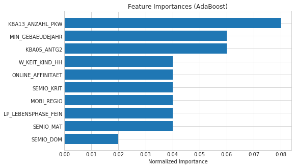

```python
plot_feature_importances(model=best_adaboost, model_name="AdaBoost", feature_names=X.columns)
```

Summary:

### Part 3: Kaggle Competition

Now that you've created a model to predict which individuals are most likely to respond to a mailout campaign, it's time to test that model in competition through Kaggle. If you click on the link here, you'll be taken to the competition page where, if you have a Kaggle account, you can enter. If you're one of the top performers, you may have the chance to be contacted by a hiring manager from Arvato or Bertelsmann for an interview!

Your entry to the competition should be a CSV file with two columns. The first column should be a copy of "LNR", which acts as an ID number for each individual in the "TEST" partition. The second column, "RESPONSE", should be some measure of how likely each individual became a customer – this might not be a straightforward probability. As you should have found in Part 2, there is a large output class imbalance, where most individuals did not respond to the mailout. Thus, predicting individual classes and using accuracy does not seem to be an appropriate performance evaluation method. Instead, the competition will be using AUC to evaluate performance. The exact values of the "RESPONSE" column do not matter as much: only that the higher values try to capture as many of the actual customers as possible, early in the ROC curve sweep.

We will read in our file

```python
df_test = pd.read_csv('../../data/Term2/capstone/arvato_data/Udacity_MAILOUT_052018_TEST.csv', sep=';')
```

```python
df_test.shape
```

```
(42833, 366)
```

```python
df_test_LNR = df_test["LNR"]
df_test_LNR.shape
```

```
(42833,)
```

```python
rn=7628
drop1 = np.random.choice(df_test_LNR.index, rn,replace=False)
df_test_LNR= df_test_LNR.drop(drop1)
```

```python
a = ['ALTERSKATEGORIE_GROB','ANREDE_KZ','CJT_GESAMTTYP','FINANZ_MINIMALIST','FINANZ_SPARER','FINANZ_VORSORGER','FINANZ_ANLEGER','FINANZ_UNAUFFAELLIGER','FINANZ_HAUSBAUER','FINANZTYP','GFK_URLAUBERTYP','GREEN_AVANTGARDE',
 'HEALTH_TYP', 'LP_LEBENSPHASE_FEIN', 'LP_LEBENSPHASE_GROB','LP_FAMILIE_FEIN','LP_FAMILIE_GROB', 'LP_STATUS_FEIN', 'LP_STATUS_GROB', 'NATIONALITAET_KZ', 'PRAEGENDE_JUGENDJAHRE', 'RETOURTYP_BK_S', 'SEMIO_SOZ',
 'SEMIO_FAM','SEMIO_REL','SEMIO_MAT','SEMIO_VERT','SEMIO_LUST','SEMIO_ERL','SEMIO_KULT','SEMIO_RAT','SEMIO_KRIT','SEMIO_DOM', 'SEMIO_KAEM', 'SEMIO_PFLICHT','SEMIO_TRADV','SHOPPER_TYP','SOHO_KZ',
 'VERS_TYP','ZABEOTYP','ANZ_PERSONEN','ANZ_TITEL','HH_EINKOMMEN_SCORE','KK_KUNDENTYP','W_KEIT_KIND_HH','WOHNDAUER_2008','ANZ_HAUSHALTE_AKTIV','ANZ_HH_TITEL','GEBAEUDETYP','KONSUMNAEHE','MIN_GEBAEUDEJAHR','OST_WEST_KZ','WOHNLAGE','CAMEO_DEUG_2015','CAMEO_DEU_2015','CAMEO_INTL_2015','KBA05_ANTG1',
 'KBA05_ANTG2','KBA05_ANTG3','KBA05_ANTG4','KBA05_GBZ','BALLRAUM','EWDICHTE','INNENSTADT','GEBAEUDETYP_RASTER','KKK','MOBI_REGIO','ONLINE_AFFINITAET','REGIOTYP','KBA13_ANZAHL_PKW','PLZ8_ANTG1','PLZ8_ANTG2','PLZ8_ANTG3','PLZ8_ANTG4','PLZ8_BAUMAX','PLZ8_HHZ','PLZ8_GBZ','ARBEIT','ORTSGR_KLS9','RELAT_AB']
```

```python
df_test1=df_test[df_test.columns[df_test.columns.isin(a)]]
```

```python
df_test1.shape
```

```
(42833, 80)
```

```python
df_test1=clean_data(df_test1)
```

```python
df_test1.shape
```

```
(35205, 79)
```

```python
df_test1.drop(['KK_KUNDENTYP'], axis = 1)
```

|  | ANZ_HAUSHALTE_AKTIV | ANZ_HH_TITEL | ANZ_PERSONEN | ANZ_TITEL | ARBEIT | BALLRAUM | CJT_GESAMTTYP | EWDICHTE | FINANZ_ANLEGER | FINANZ_HAUSBAUER | ... | SOHO_KZ | VERS_TYP | W_KEIT_KIND_HH | WOHNDAUER_2008 | WOHNLAGE | ZABEOTYP | ANREDE_KZ | ALTERSKATEGORIE_GROB | CAMEO_INTL_2015_LIFE_STAGE | CAMEO_INTL_2015_WEALTH |
| --- | --- | --- | --- | --- | --- | --- | --- | --- | --- | --- | --- | --- | --- | --- | --- | --- | --- | --- | --- | --- | --- |
| 0 | 2.0 | 0.0 | 2.0 | 0.0 | 3.0 | 6.0 | 5.0 | 5.0 | 1 | 3 | ... | 0.0 | 1 | 6.0 | 9.0 | 3.0 | 3 | 1 | 4 | 3.0 | 5.0 |
| 1 | 20.0 | 0.0 | 1.0 | 0.0 | 4.0 | 7.0 | 1.0 | 4.0 | 1 | 5 | ... | 0.0 | 1 | 6.0 | 9.0 | 5.0 | 3 | 1 | 4 | 1.0 | 3.0 |
| 2 | 2.0 | 0.0 | 4.0 | 0.0 | 4.0 | 1.0 | 2.0 | 4.0 | 1 | 4 | ... | 0.0 | 1 | 2.0 | 9.0 | 4.0 | 3 | 2 | 4 | 1.0 | 2.0 |
| 3 | 1.0 | 0.0 | 0.0 | 0.0 | 4.0 | 1.0 | 4.0 | 4.0 | 2 | 4 | ... | 0.0 | 2 | NaN | 9.0 | 2.0 | 3 | 2 | 4 | 3.0 | 5.0 |
| 4 | 1.0 | 0.0 | 4.0 | 0.0 | 3.0 | 6.0 | 6.0 | 1.0 | 3 | 2 | ... | 0.0 | 1 | 3.0 | 9.0 | 7.0 | 4 | 2 | 4 | 1.0 | 3.0 |
| 5 | 66.0 | 0.0 | 1.0 | 0.0 | 4.0 | 1.0 | 1.0 | 6.0 | 1 | 5 | ... | 0.0 | 1 | 6.0 | 9.0 | 3.0 | 6 | 1 | 4 | 1.0 | 1.0 |
| 6 | 1.0 | 0.0 | 2.0 | 0.0 | 4.0 | 6.0 | 2.0 | 3.0 | 2 | 3 | ... | 0.0 | 1 | 6.0 | 9.0 | 3.0 | 3 | 2 | 4 | 5.0 | 4.0 |
| 7 | 1.0 | 0.0 | 4.0 | 0.0 | 3.0 | 3.0 | 2.0 | 3.0 | 4 | 1 | ... | 0.0 | 1 | 2.0 | 9.0 | 3.0 | 4 | 2 | 3 | 3.0 | 2.0 |
| 8 | 2.0 | 0.0 | 4.0 | 0.0 | 2.0 | 3.0 | 1.0 | 3.0 | 1 | 2 | ... | 0.0 | 2 | 4.0 | 9.0 | 7.0 | 1 | 2 | 3 | 4.0 | 5.0 |
| 9 | 1.0 | 0.0 | 1.0 | 0.0 | 3.0 | 2.0 | 1.0 | 5.0 | 1 | 2 | ... | 0.0 | 2 | 3.0 | 4.0 | 2.0 | 4 | 1 | 3 | 3.0 | 2.0 |
| 10 | 2.0 | 0.0 | 2.0 | 0.0 | 2.0 | 7.0 | 3.0 | 2.0 | 1 | 1 | ... | 0.0 | 1 | 6.0 | 8.0 | 3.0 | 1 | 1 | 4 | 5.0 | 5.0 |
| 11 | 8.0 | 0.0 | 1.0 | 0.0 | 3.0 | 3.0 | 2.0 | 6.0 | 2 | 5 | ... | 0.0 | 1 | 6.0 | 9.0 | 4.0 | 3 | 2 | 4 | 5.0 | 2.0 |
| 12 | 1.0 | 0.0 | 4.0 | 0.0 | 2.0 | 6.0 | 4.0 | 1.0 | 5 | 2 | ... | 0.0 | 2 | 2.0 | 9.0 | 7.0 | 4 | 1 | 3 | 4.0 | 4.0 |
| 14 | 2.0 | 0.0 | 1.0 | 0.0 | 4.0 | 1.0 | 2.0 | 4.0 | 2 | 3 | ... | 0.0 | 1 | 6.0 | 9.0 | 2.0 | 3 | 2 | 4 | 4.0 | 5.0 |
| 15 | 1.0 | 0.0 | 2.0 | 0.0 | 3.0 | 6.0 | 3.0 | 2.0 | 2 | 1 | ... | 0.0 | 1 | 4.0 | 9.0 | 1.0 | 2 | 1 | 3 | 2.0 | 4.0 |
| 16 | 1.0 | 0.0 | 5.0 | 0.0 | 4.0 | 6.0 | 3.0 | 4.0 | 5 | 2 | ... | 0.0 | 1 | 6.0 | 9.0 | 1.0 | 2 | 2 | 2 | 5.0 | 3.0 |
| 17 | 10.0 | 0.0 | 1.0 | 0.0 | 5.0 | 7.0 | 3.0 | 4.0 | 2 | 5 | ... | 0.0 | 2 | 6.0 | 9.0 | 3.0 | 3 | 1 | 4 | 5.0 | 3.0 |
| 18 | 2.0 | 0.0 | 4.0 | 0.0 | 2.0 | 6.0 | 3.0 | 2.0 | 2 | 2 | ... | 0.0 | 2 | 2.0 | 9.0 | 7.0 | 1 | 1 | 4 | 4.0 | 4.0 |
| 19 | 11.0 | 0.0 | 1.0 | 0.0 | 3.0 | 7.0 | 6.0 | 6.0 | 1 | 4 | ... | 0.0 | 2 | 6.0 | 9.0 | 3.0 | 3 | 1 | 4 | 1.0 | 1.0 |
| 20 | 2.0 | 0.0 | 5.0 | 0.0 | 4.0 | 1.0 | 2.0 | 5.0 | 1 | 2 | ... | 0.0 | 2 | 3.0 | 8.0 | 2.0 | 3 | 2 | 3 | 1.0 | 3.0 |
| 21 | 2.0 | 0.0 | 4.0 | 0.0 | 3.0 | 6.0 | 2.0 | 2.0 | 2 | 3 | ... | 0.0 | 2 | 2.0 | 9.0 | 3.0 | 3 | 2 | 4 | 2.0 | 4.0 |
| 22 | 1.0 | 0.0 | 2.0 | 0.0 | 3.0 | 1.0 | 3.0 | 6.0 | 1 | 4 | ... | 0.0 | 2 | 6.0 | 9.0 | 2.0 | 1 | 2 | 4 | 4.0 | 2.0 |
| 23 | 2.0 | 0.0 | 2.0 | 0.0 | 1.0 | 2.0 | 2.0 | 4.0 | 1 | 3 | ... | 0.0 | 2 | 6.0 | 9.0 | 7.0 | 3 | 2 | 4 | 2.0 | 4.0 |
| 24 | 12.0 | 0.0 | 1.0 | 0.0 | 3.0 | 6.0 | 1.0 | 6.0 | 1 | 5 | ... | 0.0 | 2 | 6.0 | 9.0 | 3.0 | 3 | 2 | 4 | 1.0 | 2.0 |
| 25 | 1.0 | 0.0 | 4.0 | 0.0 | 4.0 | 6.0 | 1.0 | 5.0 | 1 | 1 | ... | 0.0 | 2 | 4.0 | 9.0 | 3.0 | 1 | 1 | 3 | 4.0 | 5.0 |
| 26 | 1.0 | 0.0 | 2.0 | 0.0 | 5.0 | 1.0 | 3.0 | 5.0 | 1 | 2 | ... | 0.0 | 1 | 6.0 | 9.0 | 1.0 | 1 | 1 | 4 | 4.0 | 4.0 |
| 27 | 1.0 | 0.0 | 1.0 | 0.0 | 2.0 | 6.0 | 5.0 | 2.0 | 5 | 1 | ... | 0.0 | 1 | 3.0 | 9.0 | 7.0 | 3 | 2 | 4 | 4.0 | 4.0 |
| 28 | 1.0 | 0.0 | 2.0 | 0.0 | 4.0 | 6.0 | 2.0 | 4.0 | 1 | 2 | ... | 0.0 | -1 | 6.0 | 9.0 | 2.0 | 3 | 1 | 1 | 4.0 | 5.0 |
| 30 | 2.0 | 0.0 | 6.0 | 0.0 | 3.0 | 7.0 | 4.0 | 2.0 | 5 | 4 | ... | 0.0 | 1 | 2.0 | 9.0 | 7.0 | 4 | 2 | 4 | 5.0 | 4.0 |
| 31 | 1.0 | 0.0 | 2.0 | 0.0 | 1.0 | 7.0 | 2.0 | 3.0 | 2 | 3 | ... | 0.0 | 2 | 6.0 | 9.0 | 7.0 | 1 | 1 | 4 | 3.0 | 2.0 |

[output cut: 471 more lines]

35205 rows × 78 columns

```python
df_test1= df_test1.fillna(df_test1.mode().iloc[0])
```

```python
best_adaboost.fit(X, y)
```

```
AdaBoostClassifier(algorithm='SAMME.R', base_estimator=None,
          learning_rate=0.9, n_estimators=50, random_state=2)
```

```python
preds_test_adaboost = best_adaboost.predict_proba(df_test1)[:,1]
```

```python
kaggle_submi = pd.DataFrame(index=df_test_LNR, data=preds_test_adaboost)
kaggle_submi.rename(columns={0: "RESPONSE"}, inplace=True)
```

```python
kaggle_submi.head()
```

| LNR | RESPONSE |
| --- | --- |
| 1754 | 0.494576 |
| 1770 | 0.494992 |
| 1465 | 0.496007 |
| 1470 | 0.493234 |
| 1478 | 0.492911 |

```python
#kaggle_submi.to_csv('KaggleSubmission.csv')
```

### Conclusion

###### Reflection:

One of the major factor that made this project a bit tedious is the time taken for the code cells to run. This is mostly due to the size of the dataset being worked upon for the project. Fitting our adboost model was also time consuming due to computational reasons.

###### Improvement:

This project can be improved on by using other models will higher scores. All the model investigated in the project had AUCROC_score less than 0.7. Hence, for further research, more efficient model with higher scores can be deployed